# Notebook

## 253_spatial_operations_gvp_reclustering.ipynb

**This script provides the re-clustering methods for the given original Smithsonion Institution GVP (Global Volcanoe Program) volcanic areas around the "Pacific Ring of Fire".** The main parts of the routines were developed in previous courses at the University of London by the same author (Mohr, 2021, 2023, 2024a) and have been further refined to meet the needs of this MSc thesis project/research. However, the code has been updated to comply with the latest requirements and package interdependencies. Some comments will be included in this Jupyter Notebook, and the code contains several inline comments. For details on the project/research itself, refer to the appropriate document.

#### References (for this script)

*Mohr, S. (2021) Regional Spatial Clusters of Earthquakes at the Pacific Ring of Fire: Analysing Data from the USGS ANSS ComCat and Building Regional Spatial Clusters. DSM020, Python, examined coursework cw1. University of London.*

*Mohr, S. (2023) Clustering of Earthquakes on a Worldwide Scale with the Help of Big Data Machine Learning Methods. DSM010, Big Data, examined coursework cw2. University of London.*

*Mohr, S. (2024a) Comparing Different Tectonic Setups Considering Publicly Available Basic Earthquake’s Data. DSM050, Data Visualisation, examined coursework cw1. University of London.*

#### History

```
250124 Generation of script from skeleton of 50_timeseries_analysis and xx_cluster_volcanoes, cleaning up and combining
       all previous tests, collect other code snippets
250125 Add and test all clustering methods, add and test all metrics
250126 Create procedures procedures, optimise clustering, decide on number of cluster per clustering method,
       make metrics result tables and ranking, check meaning of external clustering (okay),
```

#### Todo

```
+ create a new volcano datataset based on the chosen new cluster method
+ create eruptions and earthquakes datasets according to the volcanic clusters
+ safe all 3 datasets to the appropriate scope folder
```

## Preparing the environment

### System information

```python
# which python installation and version are we using here?
print('\n******* Python Info ***********')
!which python
!python --version

# show some CPU and RAM info
print('\n******* CPU Info ***********')
!lscpu
print('\n******* RAM Info (in GB) ***********')
!free -g
```

```
******* Python Info ***********
/bin/python
Python 3.8.10

******* CPU Info ***********
Architecture:                       x86_64
CPU op-mode(s):                     32-bit, 64-bit
Byte Order:                         Little Endian
Address sizes:                      46 bits physical, 48 bits virtual
CPU(s):                             64
On-line CPU(s) list:                0-63
Thread(s) per core:                 2
Core(s) per socket:                 8
Socket(s):                          4
NUMA node(s):                       4
Vendor ID:                          GenuineIntel
CPU family:                         6
Model:                              85
Model name:                         Intel(R) Xeon(R) Gold 6234 CPU @ 3.30GHz
Stepping:                           7
CPU MHz:                            1200.059
CPU max MHz:                        4000.0000
CPU min MHz:                        1200.0000
BogoMIPS:                           6600.00
Virtualization:                     VT-x
L1d cache:                          1 MiB
L1i cache:                          1 MiB
L2 cache:                           32 MiB
L3 cache:                           99 MiB
NUMA node0 CPU(s):                  0,4,8,12,16,20,24,28,32,36,40,44,48,52,56,60
NUMA node1 CPU(s):                  1,5,9,13,17,21,25,29,33,37,41,45,49,53,57,61
NUMA node2 CPU(s):                  2,6,10,14,18,22,26,30,34,38,42,46,50,54,58,6
                                    2
NUMA node3 CPU(s):                  3,7,11,15,19,23,27,31,35,39,43,47,51,55,59,6
                                    3
Vulnerability Gather data sampling: Mitigation; Microcode
Vulnerability Itlb multihit:        KVM: Mitigation: Split huge pages
Vulnerability L1tf:                 Not affected
Vulnerability Mds:                  Not affected
Vulnerability Meltdown:             Not affected
```

[output cut: 24 more lines]

[output not shown]

```python
# show installed packages and versions
!pip freeze
```

[output not shown]

[output cut: 203 more lines]

[output not shown]

### Setting PATH correctly

```python
# there is somewhere a PATH-error on LENA for a while
# adding my packages path to the PATH environment

import sys
sys.path.append("/home/smohr001/.local/lib/python3.8/site-packages")
sys.path
```

```
['/home/smohr001/thesis',
 '/usr/lib/python38.zip',
 '/usr/lib/python3.8',
 '/usr/lib/python3.8/lib-dynload',
 '',
 '/opt/jupyterhub/lib/python3.8/site-packages',
 '/opt/jupyterhub/lib/python3.8/site-packages/IPython/extensions',
 '/home/smohr001/.ipython',
 '/home/smohr001/.local/lib/python3.8/site-packages']
```

### Loading libraries

```python
# importing standard libraries
import sys
import os
import warnings
import datetime
import time
import math
import numpy as np
import pandas as pd
import matplotlib.pyplot as plt
import seaborn as sns
import random
import logging
from IPython.display import display, Javascript

# importing shared procedures for this procect (needs to be a simple .py file)
%run shared_procedures.py

# importing additional libraries
import matplotlib.patches as mpatches

import geopandas as gpd
from shapely import wkt
import geodatasets
from shapely.ops import unary_union

from sklearn.preprocessing import StandardScaler, MinMaxScaler, RobustScaler
from sklearn.metrics import silhouette_score, calinski_harabasz_score, davies_bouldin_score
from sklearn.metrics import jaccard_score, adjusted_rand_score, fowlkes_mallows_score
from sklearn.mixture import GaussianMixture
from sklearn.cluster import KMeans, DBSCAN, AgglomerativeClustering, SpectralClustering, Birch
from sklearn.neighbors import KNeighborsClassifier

from clustpy.density import MultiDensityDBSCAN
from clustpy.deep import IDEC

from scipy.spatial.distance import cdist
from scipy.cluster.hierarchy import linkage

# get info about installed and used versions of some important (deep learning) libraries
print("Some important installed libraries:\n")
print(f"Pandas version: {pd.__version__}")
print(f"Numpy version: {np.__version__}")
print(f"Seaborn version: {sns.__version__}")
```

```
Some important installed libraries:

Pandas version: 1.4.1
Numpy version: 1.22.2
Seaborn version: 0.13.2
```

### Setting the script environment

```python
# import the parameters (foreced to reload)
import parameters
import importlib
importlib.reload(parameters)

# # print all loaded parameters from the Python file
print_loaded_parameters(parameters)
```

```
Loaded Parameters:

parameters.buffer_size_km = 1000
parameters.data_dir = data/scope/reclustered_1000
parameters.data_dir_raw = data
parameters.data_ts_dir = data/scope/reclustered_1000
parameters.scope_id = gvp_reclustered_1000
```

```python
# show all matplotlib graphs inline
%matplotlib inline

# setting format to JPG for easy copy & paste for figures
# for high quality outputs choose 'svg'
%config InlineBackend.figure_format = 'jpg'

# adjust display settings to show 20 rows as a standard
pd.set_option('display.max_rows', 20)

# disable warnings (activate after developing the complete code)
warnings.filterwarnings('ignore')

# set script (ipynb notebook) name (e.g. for logging)
script_name = "253_spatial_operations_gvp_reclustering.ipynb"

# start parameterized logging
setup_logging(logfile_dir = "log",
              logfile_name = "25_spatial_operations.log",
              log_level = logging.INFO,
              script_name = script_name
             )

# set data directory
if(parameters.data_dir_raw):
    data_dir_raw = parameters.data_dir_raw
else:
    data_dir_raw = "data"
logging.info(f"{script_name}: Set raw data directory to './{data_dir_raw}'.")

if(parameters.data_dir):
    data_dir = parameters.data_dir
else:
    data_dir = "data"
logging.info(f"{script_name}: Set scope data directory to './{data_dir}'.")

if(parameters.data_ts_dir):
    data_ts_dir = parameters.data_ts_dir
else:
    data_ts_dir = "data/timeseries"
logging.info(f"{script_name}: Set scope timeseries data directory to './{data_ts_dir}'.")
```

```
2025-01-26 21:08:11,984 - INFO - Starting script '253_spatial_operations_gvp_reclustering.ipynb'.
2025-01-26 21:08:11,985 - INFO - Set loglevel to INFO.
2025-01-26 21:08:11,986 - INFO - 253_spatial_operations_gvp_reclustering.ipynb: Set raw data directory to './data'.
2025-01-26 21:08:11,987 - INFO - 253_spatial_operations_gvp_reclustering.ipynb: Set scope data directory to './data/scope/reclustered_1000'.
2025-01-26 21:08:11,988 - INFO - 253_spatial_operations_gvp_reclustering.ipynb: Set scope timeseries data directory to './data/scope/reclustered_1000'.
```

```python
# set fixed seed for reproducibility
reset_random_seeds(script_name=script_name)
```

```
2025-01-26 21:08:11,993 - INFO - 253_spatial_operations_gvp_reclustering.ipynb: Seeding random generators with seed=654321.
```

## Loading data

```python
# load datasets
earthquakes_selected = load_dataset(data_file="earthquakes_selected.csv", data_dir=data_dir_raw)
volcanoes_selected = load_dataset(data_file="volcanoes_selected.csv", data_dir=data_dir_raw)
eruptions_selected = load_dataset(data_file="eruptions_selected.csv", data_dir=data_dir_raw)
```

```
2025-01-26 21:08:12,156 - INFO - load_dataset: Data loaded successfully from 'data/earthquakes_selected.csv'.
2025-01-26 21:08:12,161 - INFO - load_dataset: Data loaded successfully from 'data/volcanoes_selected.csv'.
2025-01-26 21:08:12,166 - INFO - load_dataset: Data loaded successfully from 'data/eruptions_selected.csv'.
```

## Statistics and information

```python
# infos of the dataset
print("\nShape:\n" + str(earthquakes_selected.shape))
print("\nColumns and DataTypes:\n" + str(earthquakes_selected.dtypes))
display(earthquakes_selected)
logging.info(f"{script_name}: Used dataset is 'earthquakes_selected' with {earthquakes_selected.shape}.")

# infos of the dataset
print("\nShape:\n" + str(volcanoes_selected.shape))
print("\nColumns and DataTypes:\n" + str(volcanoes_selected.dtypes))
display(volcanoes_selected)
logging.info(f"{script_name}: Used dataset is 'volcanoes_selected' with {volcanoes_selected.shape}.")

# infos of the dataset
print("\nShape:\n" + str(eruptions_selected.shape))
print("\nColumns and DataTypes:\n" + str(eruptions_selected.dtypes))
display(eruptions_selected)
logging.info(f"{script_name}: Used dataset is 'eruptions_selected' with {volcanoes_selected.shape}.")
```

```
Shape:
(63773, 20)

Columns and DataTypes:
id           object
geo_x       float64
geo_y       float64
timeymd      object
year          int64
lon         float64
lat         float64
depth       float64
mag         float64
time          int64
felt        float64
cdi         float64
mmi         float64
alert        object
status       object
tsunami       int64
nst           int64
net          object
sig         float64
geometry     object
dtype: object
```

|  | id | geo_x | geo_y | timeymd | year | lon | lat | depth | mag | time | felt | cdi | mmi | alert | status | tsunami | nst | net | sig | geometry |
| --- | --- | --- | --- | --- | --- | --- | --- | --- | --- | --- | --- | --- | --- | --- | --- | --- | --- | --- | --- | --- |
| 0 | iscgem799554 | 276.6450 | 8.5430 | 1970-01-01 | 1970 | -83.3550 | 8.5430 | 15.00 | 5.44 | 6226830 | NaN | NaN | NaN | NaN | reviewed | 0 | 455 | iscgem | NaN | POINT (-83.355 8.543) |
| 1 | iscgem799588 | 182.8310 | -29.4000 | 1970-01-01 | 1970 | -177.1690 | -29.4000 | 35.00 | 5.61 | 61860630 | NaN | NaN | NaN | NaN | reviewed | 0 | 484 | iscgem | NaN | POINT (-177.169 -29.4) |
| 2 | iscgem799702 | 121.9190 | 0.3120 | 1970-01-04 | 1970 | 121.9190 | 0.3120 | 146.40 | 5.54 | 289882530 | NaN | NaN | NaN | NaN | reviewed | 0 | 472 | iscgem | NaN | POINT (121.919 0.312) |
| 3 | iscgem799712 | 102.5430 | 24.1850 | 1970-01-04 | 1970 | 102.5430 | 24.1850 | 11.30 | 7.10 | 320441090 | NaN | NaN | 8.862 | NaN | reviewed | 0 | 776 | iscgem | NaN | POINT (102.543 24.185) |
| 4 | iscgem799715 | 102.4390 | 24.1800 | 1970-01-04 | 1970 | 102.4390 | 24.1800 | 15.00 | 5.56 | 322359090 | NaN | NaN | NaN | NaN | reviewed | 0 | 476 | iscgem | NaN | POINT (102.439 24.18) |
| ... | ... | ... | ... | ... | ... | ... | ... | ... | ... | ... | ... | ... | ... | ... | ... | ... | ... | ... | ... | ... |
| 63768 | pr2019363002 | 293.1360 | 17.8846 | 2019-12-29 | 2019 | -66.8640 | 17.8846 | 6.00 | 5.00 | 1577581560130 | 339.0 | 5.5 | 5.426 | green | reviewed | 0 | 571 | pr | 18.0 | POINT (-66.864 17.8846) |
| 63769 | us70006s54 | 125.3963 | 4.6867 | 2019-12-29 | 2019 | 125.3963 | 4.6867 | 23.96 | 5.40 | 1577610735869 | NaN | NaN | 3.748 | green | reviewed | 0 | 449 | us | NaN | POINT (125.3963 4.6867) |
| 63770 | us70006s6z | 151.7733 | -5.5011 | 2019-12-29 | 2019 | 151.7733 | -5.5011 | 35.00 | 5.10 | 1577627942410 | NaN | NaN | NaN | NaN | reviewed | 0 | 400 | us | NaN | POINT (151.7733 -5.5011) |
| 63771 | us70006sbu | 142.8218 | 27.8371 | 2019-12-30 | 2019 | 142.8218 | 27.8371 | 17.30 | 5.10 | 1577679070184 | 1.0 | 3.4 | NaN | NaN | reviewed | 0 | 400 | us | NaN | POINT (142.8218 27.8371) |
| 63772 | us70006suy | 181.5247 | -33.6142 | 2019-12-31 | 2019 | -178.4753 | -33.6142 | 10.00 | 5.00 | 1577791369734 | NaN | NaN | NaN | NaN | reviewed | 0 | 385 | us | NaN | POINT (-178.4753 -33.6142) |

63773 rows × 20 columns

```
2025-01-26 21:08:12,204 - INFO - 253_spatial_operations_gvp_reclustering.ipynb: Used dataset is 'earthquakes_selected' with (63773, 20).
```

```
Shape:
(201, 16)

Columns and DataTypes:
Volcano_Number            int64
geo_x                   float64
geo_y                   float64
Volcano_Name             object
Primary_Volcano_Type     object
Country                  object
Region                   object
Latitude                float64
Longitude               float64
Elevation                 int64
Tectonic_Setting         object
Evidence_Category        object
Major_Rock_Type          object
Erupting                   bool
Last_Activity_Year      float64
geometry                 object
dtype: object
```

|  | Volcano_Number | geo_x | geo_y | Volcano_Name | Primary_Volcano_Type | Country | Region | Latitude | Longitude | Elevation | Tectonic_Setting | Evidence_Category | Major_Rock_Type | Erupting | Last_Activity_Year | geometry |
| --- | --- | --- | --- | --- | --- | --- | --- | --- | --- | --- | --- | --- | --- | --- | --- | --- |
| 0 | 241040 | 177.1800 | -37.5200 | Whakaari/White Island | Stratovolcano(es) | New Zealand | Tonga-Kermadec Volcanic Regions | -37.5200 | 177.1800 | 294 | Subduction zone / Continental crust (> 25 km) | Eruption Observed | Andesite / Basaltic Andesite | True | 2019.0 | POINT (177.18 -37.52) |
| 1 | 241050 | 176.5069 | -38.1569 | Okataina | Lava dome(s) | New Zealand | Tonga-Kermadec Volcanic Regions | -38.1569 | 176.5069 | 1111 | Subduction zone / Continental crust (> 25 km) | Eruption Observed | Rhyolite | True | 1981.0 | POINT (176.5069 -38.1569) |
| 2 | 241080 | 175.6320 | -39.1570 | Tongariro | Stratovolcano(es) | New Zealand | Tonga-Kermadec Volcanic Regions | -39.1570 | 175.6320 | 1978 | Subduction zone / Continental crust (> 25 km) | Eruption Observed | Andesite / Basaltic Andesite | True | 2012.0 | POINT (175.632 -39.157) |
| 3 | 241100 | 175.5700 | -39.2800 | Ruapehu | Stratovolcano(es) | New Zealand | Tonga-Kermadec Volcanic Regions | -39.2800 | 175.5700 | 2797 | Subduction zone / Continental crust (> 25 km) | Eruption Observed | Andesite / Basaltic Andesite | True | 2007.0 | POINT (175.57 -39.28) |
| 4 | 242030 | 182.0800 | -29.2700 | Raoul Island | Stratovolcano(es) | New Zealand | Tonga-Kermadec Volcanic Regions | -29.2700 | -177.9200 | 516 | Subduction zone / Oceanic crust (< 15 km) | Eruption Observed | Andesite / Basaltic Andesite | True | 2006.0 | POINT (-177.92 -29.27) |
| ... | ... | ... | ... | ... | ... | ... | ... | ... | ... | ... | ... | ... | ... | ... | ... | ... |
| 196 | 358041 | 287.3486 | -42.8349 | Chaiten | Caldera | Chile | South America Volcanic Regions | -42.8349 | -72.6514 | 1122 | Subduction zone / Continental crust (> 25 km) | Eruption Observed | Rhyolite | True | 2011.0 | POINT (-72.6514 -42.8349) |
| 197 | 358057 | 287.0300 | -45.9000 | Hudson, Cerro | Stratovolcano(es) | Chile | South America Volcanic Regions | -45.9000 | -72.9700 | 1905 | Subduction zone / Continental crust (> 25 km) | Eruption Observed | Basalt / Picro-Basalt | True | 2011.0 | POINT (-72.97 -45.9) |
| 198 | 358060 | 286.4960 | -49.0190 | Lautaro | Stratovolcano(es) | Chile | South America Volcanic Regions | -49.0190 | -73.5040 | 3542 | Subduction zone / Continental crust (> 25 km) | Eruption Observed | Dacite | True | 1979.0 | POINT (-73.504 -49.019) |
| 199 | 284193 | 145.7800 | 16.5800 | South Sarigan Seamount | Stratovolcano(es) | United States | Northwest Pacific Volcanic Regions | 16.5800 | 145.7800 | -184 | Subduction zone / Crustal thickness unknown | Eruption Observed | unknown | True | 2010.0 | POINT (145.78 16.58) |
| 200 | 242005 | 180.9670 | -31.0800 | Havre Seamount | Stratovolcano(es) | New Zealand | Tonga-Kermadec Volcanic Regions | -31.0800 | -179.0330 | -897 | Subduction zone / Oceanic crust (< 15 km) | Eruption Observed | unknown | True | 2012.0 | POINT (-179.033 -31.08) |

201 rows × 16 columns

```
2025-01-26 21:08:12,217 - INFO - 253_spatial_operations_gvp_reclustering.ipynb: Used dataset is 'volcanoes_selected' with (201, 16).
```

```
Shape:
(1252, 13)

Columns and DataTypes:
Volcano_Number           int64
Eruption_Number          int64
Activity_Type           object
ExplosivityIndexMax    float64
StartEvidenceMethod     object
StartDateYear            int64
StartDateMonth         float64
StartDateDay           float64
EndDateYear            float64
EndDateMonth           float64
EndDateDay             float64
StartDate               object
EndDate                 object
dtype: object
```

|  | Volcano_Number | Eruption_Number | Activity_Type | ExplosivityIndexMax | StartEvidenceMethod | StartDateYear | StartDateMonth | StartDateDay | EndDateYear | EndDateMonth | EndDateDay | StartDate | EndDate |
| --- | --- | --- | --- | --- | --- | --- | --- | --- | --- | --- | --- | --- | --- |
| 0 | 257020 | 20938 | Confirmed Eruption | 1.0 | Observations: Reported | 2011 | 9.0 | 17.0 | 2011.0 | 10.0 | 10.0 | 2011-09-17 | 2011-10-10 |
| 1 | 257020 | 15226 | Confirmed Eruption | 2.0 | Observations: Reported | 1976 | 1.0 | 15.0 | 1976.0 | 1.0 | 15.0 | 1976-01-15 | 1976-01-15 |
| 2 | 257020 | 15227 | Confirmed Eruption | 2.0 | Observations: Reported | 1977 | 4.0 | 13.0 | 1977.0 | 4.0 | 13.0 | 1977-04-13 | 1977-04-13 |
| 3 | 257020 | 15228 | Confirmed Eruption | 1.0 | Observations: Reported | 1980 | 7.0 | 2.0 | 1980.0 | 7.0 | 2.0 | 1980-07-02 | 1980-07-02 |
| 4 | 257020 | 15229 | Confirmed Eruption | 1.0 | Observations: Reported | 1981 | 7.0 | 9.0 | 1981.0 | 7.0 | 9.0 | 1981-07-09 | 1981-07-09 |
| ... | ... | ... | ... | ... | ... | ... | ... | ... | ... | ... | ... | ... | ... |
| 1247 | 341040 | 10460 | Confirmed Eruption | 1.0 | Observations: Reported | 1977 | 12.0 | 16.0 | 1982.0 | 6.0 | 16.0 | 1977-12-16 | 1982-06-16 |
| 1248 | 341040 | 10461 | Uncertain Eruption | 1.0 | unknown | 1983 | 2.0 | 11.0 | 1983.0 | 2.0 | 15.0 | 1983-02-11 | 1983-02-15 |
| 1249 | 357010 | 11899 | Confirmed Eruption | 2.0 | Observations: Reported | 1987 | 11.0 | 28.0 | 1987.0 | 11.0 | 30.0 | 1987-11-28 | 1987-11-30 |
| 1250 | 357010 | 20561 | Confirmed Eruption | 2.0 | Observations: Reported | 1980 | 1.0 | 10.0 | 1980.0 | 1.0 | 11.0 | 1980-01-10 | 1980-01-11 |
| 1251 | 357010 | 11898 | Confirmed Eruption | 1.0 | Observations: Reported | 1986 | 1.0 | 20.0 | 1986.0 | 1.0 | 20.0 | 1986-01-20 | 1986-01-20 |

1252 rows × 13 columns

[output not shown]

## Setting correct datatypes

```python
# define (target) data types for volcanoes
set_types_volcanoes = {'Volcano_Number': 'int64',
                       'Volcano_Name': 'object',
                       'Primary_Volcano_Type': 'object',
                       'Last_Activity_Year': 'int64',
                       'Country': 'object',
                       'Region': 'object',
                       'Latitude': 'float64',
                       'Longitude': 'float64',
                       'Elevation': 'int64',
                       'Tectonic_Setting': 'object',
                       'Evidence_Category': 'object',
                       'Major_Rock_Type': 'object'
                      }

# check and convert datatypes
print("Volcanoes checking.")
check_data_types_of_dataframe(volcanoes_selected, set_types_volcanoes)
print("\nVolcanoes correcting.")
volcanoes_selected = convert_data_types_of_dataframe(volcanoes_selected, set_types_volcanoes)
```

```
Volcanoes checking.
Checking datatypes (no output means nothing to correct):

Last_Activity_Year: float64 --> int64

Volcanoes correcting.
Column 'Volcano_Number' converted to int64.
Column 'Volcano_Name' converted to object.
Column 'Primary_Volcano_Type' converted to object.
Column 'Last_Activity_Year' converted to int64.
Column 'Country' converted to object.
Column 'Region' converted to object.
Column 'Latitude' converted to float64.
Column 'Longitude' converted to float64.
Column 'Elevation' converted to int64.
Column 'Tectonic_Setting' converted to object.
Column 'Evidence_Category' converted to object.
Column 'Major_Rock_Type' converted to object.
```

```python
# define (target) data types for eruptions
set_types_eruptions = {'Volcano_Number': 'int64',
                       'Eruption_Number': 'int64',
                       'Activity_Type': 'object',
                       'ExplosivityIndexMax': 'int64',
                       'StartEvidenceMethod': 'object',
                       'StartDateYear': 'int64',
                       'StartDateMonth': 'int64',
                       'StartDateDay': 'int64',
                       'EndDateYear': 'int64',
                       'EndDateMonth': 'int64',
                       'EndDateDay': 'int64',
                       'StartDate': 'datetime64[ns]',
                       'EndDate': 'datetime64[ns]'
                      }

# check and convert datatypes
print("Eruptions checking.")
check_data_types_of_dataframe(eruptions_selected, set_types_eruptions)
print("\nEruptions")
eruptions_selected = convert_data_types_of_dataframe(eruptions_selected, set_types_eruptions)
```

```
Eruptions checking.
Checking datatypes (no output means nothing to correct):

ExplosivityIndexMax: float64 --> int64
StartDateMonth: float64 --> int64
StartDateDay: float64 --> int64
EndDateYear: float64 --> int64
EndDateMonth: float64 --> int64
EndDateDay: float64 --> int64
StartDate: object --> datetime64[ns]
EndDate: object --> datetime64[ns]

Eruptions
Column 'Volcano_Number' converted to int64.
Column 'Eruption_Number' converted to int64.
Column 'Activity_Type' converted to object.
Column 'ExplosivityIndexMax' converted to int64.
Column 'StartEvidenceMethod' converted to object.
Column 'StartDateYear' converted to int64.
Column 'StartDateMonth' converted to int64.
Column 'StartDateDay' converted to int64.
Column 'EndDateYear' converted to int64.
Column 'EndDateMonth' converted to int64.
Column 'EndDateDay' converted to int64.
Column 'StartDate' converted to datetime64[ns].
Column 'EndDate' converted to datetime64[ns].
```

```python
#define (target) data types
set_types_earthquakes = {'geo_y': 'float64',
                         'geo_x': 'float64',
                         'lon': 'float64',
                         'lat': 'float64',
                         'depth': 'float64',
                         'mag': 'float64',
                         'time': 'int64',
                         'felt': 'float64',
                         'cdi': 'float64',
                         'mmi': 'float64',
                         'tsunami': 'int64',
                         'nst': 'int64',
                         'sig': 'float64',
                         'id': 'object',
                         'alert': 'object',
                         'status': 'object',
                         'net': 'object',
                         'year': 'int64',          # must be int64 for visualisation
                         'timeymd': 'datetime64',
                         'geometry': 'str'
                        }

# check and convert datatypes
print("Earthquakes checking.")
check_data_types_of_dataframe(earthquakes_selected, set_types_earthquakes)
print("\nEarthquakes correcting.")
earthquakes_selected = convert_data_types_of_dataframe(earthquakes_selected, set_types_earthquakes)
```

```
Earthquakes checking.
Checking datatypes (no output means nothing to correct):

timeymd: object --> datetime64
geometry: object --> str

Earthquakes correcting.
Column 'geo_y' converted to float64.
Column 'geo_x' converted to float64.
Column 'lon' converted to float64.
Column 'lat' converted to float64.
Column 'depth' converted to float64.
Column 'mag' converted to float64.
Column 'time' converted to int64.
Column 'felt' converted to float64.
Column 'cdi' converted to float64.
Column 'mmi' converted to float64.
Column 'tsunami' converted to int64.
Column 'nst' converted to int64.
Column 'sig' converted to float64.
Column 'id' converted to object.
Column 'alert' converted to object.
Column 'status' converted to object.
Column 'net' converted to object.
Column 'year' converted to int64.
Column 'timeymd' converted to datetime64.
Column 'geometry' converted to str.
```

## Preparation

```python
# handling of spatial geometry point information (pre-applying the right format)
print("Columns 'geometry' pre-converted with WKT information (prepared for POINT conversion).")
earthquakes_selected['geometry'] = earthquakes_selected['geometry'].apply(wkt.loads)
volcanoes_selected['geometry'] = volcanoes_selected['geometry'].apply(wkt.loads)

# convert the DataFrame to a GeoDataFrame in Mercator Projection (EPSG:3857) or WGS84 (EPSG:4326)
earthquakes_selected_gdf = gpd.GeoDataFrame(earthquakes_selected, geometry='geometry', crs="EPSG:4326")
volcanoes_selected_gdf = gpd.GeoDataFrame(volcanoes_selected, geometry='geometry', crs="EPSG:4326")

# get world data
world = gpd.read_file(geodatasets.get_path("naturalearth.land"))

# load the Tectonic Plate shapefile
plates_gdf = gpd.read_file('shapefiles/Plate_Boundaries.shp')

# show the CRS
print("\nEPSG earthquakes_selected_gdf: ", earthquakes_selected_gdf.crs)
print("EPSG volcanoes_selected_gdf: ", volcanoes_selected_gdf.crs)
print("EPSG world: ", world.crs)
print("EPSG plates: ", plates_gdf.crs)
```

```
Columns 'geometry' pre-converted with WKT information (prepared for POINT conversion).

EPSG earthquakes_selected_gdf:  EPSG:4326
EPSG volcanoes_selected_gdf:  EPSG:4326
EPSG world:  EPSG:4326
EPSG plates:  EPSG:4326
```

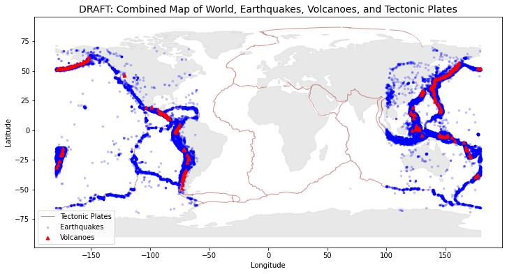

```python
# Plot each dataset on the same axis
fig, ax = plt.subplots(figsize=(12, 8))
world.plot(ax=ax, color='lightgrey', edgecolor='lightgrey', alpha=0.5, zorder=1)
plates_gdf.plot(ax=ax, edgecolor='brown', linewidth=1.0, alpha=0.5, label='Tectonic Plates', zorder=2)
earthquakes_selected_gdf.plot(ax=ax, color='blue', marker='o', label='Earthquakes', alpha=0.2, markersize=6, zorder=3)
volcanoes_selected_gdf.plot(ax=ax, color='red', marker='^', label='Volcanoes', alpha=1.0, markersize=24, zorder=4)
ax.legend()
ax.set_title('DRAFT: Combined Map of World, Earthquakes, Volcanoes, and Tectonic Plates', fontsize=14)
ax.set_xlabel('Longitude')
ax.set_ylabel('Latitude')
plt.show()
```

## Dictionaries (for coding)

### GVP Volcanic Regions cluster codes

```python
# make a dictionary for (original) GVP volcanic regions

# get the values one time and then use fixed values
# gvp_volcanoc_regions_dict = {i: region for i, region in enumerate(volcanoes_selected_gdf['Region'].unique(), start=1)}

# now set this to fixed vakues and use the previously used codes (from the other spatial operation scripts)
gvp_volcanoc_regions_dict = {
    1: "North America Volcanic Regions",
    2: "Sunda-Banda Volcanic Regions",
    3: "South America Volcanic Regions",
    4: "Western Pacific Volcanic Regions",
    5: "Southwest Pacific Volcanic Regions",
    6: "Tonga-Kermadec Volcanic Regions",
    7: "Northwest Pacific Volcanic Regions",
    8: "Middle America-Caribbean Volcanic Regions"
}

print("Dictionary 'gvp_volcanoc_regions_dict' for (original) GVP volcanic region")
print("-------------------------------------------------------------------------")
for key, value in gvp_volcanoc_regions_dict.items():
    print(f"{key}: {value}")
```

```
Dictionary 'gvp_volcanoc_regions_dict' for (original) GVP volcanic region
-------------------------------------------------------------------------
1: North America Volcanic Regions
2: Sunda-Banda Volcanic Regions
3: South America Volcanic Regions
4: Western Pacific Volcanic Regions
5: Southwest Pacific Volcanic Regions
6: Tonga-Kermadec Volcanic Regions
7: Northwest Pacific Volcanic Regions
8: Middle America-Caribbean Volcanic Regions
```

## Compose dataset for clustering

Use only those data which is relevant for clustering, omit any other data. Use only normalised or encoded data.

```python
# copy all necessary columns to a new dataframe
volcanoes_selected_gdf_clustering = volcanoes_selected_gdf[
    ['Volcano_Number', 'Volcano_Name', 'geo_x', 'geo_y']
].copy()

# infos of the dataset
print("\nShape:\n" + str(volcanoes_selected_gdf_clustering.shape))
print("\nColumns and DataTypes:\n" + str(volcanoes_selected_gdf_clustering.dtypes))
display(volcanoes_selected_gdf_clustering)
logging.info(f"{script_name}: Used dataset is 'volcanoes_selected_gdf_clustering' with {volcanoes_selected_gdf_clustering.shape}.")
```

```
Shape:
(201, 4)

Columns and DataTypes:
Volcano_Number      int64
Volcano_Name       object
geo_x             float64
geo_y             float64
dtype: object
```

|  | Volcano_Number | Volcano_Name | geo_x | geo_y |
| --- | --- | --- | --- | --- |
| 0 | 241040 | Whakaari/White Island | 177.1800 | -37.5200 |
| 1 | 241050 | Okataina | 176.5069 | -38.1569 |
| 2 | 241080 | Tongariro | 175.6320 | -39.1570 |
| 3 | 241100 | Ruapehu | 175.5700 | -39.2800 |
| 4 | 242030 | Raoul Island | 182.0800 | -29.2700 |
| ... | ... | ... | ... | ... |
| 196 | 358041 | Chaiten | 287.3486 | -42.8349 |
| 197 | 358057 | Hudson, Cerro | 287.0300 | -45.9000 |
| 198 | 358060 | Lautaro | 286.4960 | -49.0190 |
| 199 | 284193 | South Sarigan Seamount | 145.7800 | 16.5800 |
| 200 | 242005 | Havre Seamount | 180.9670 | -31.0800 |

201 rows × 4 columns

```
2025-01-26 21:08:15,158 - INFO - 253_spatial_operations_gvp_reclustering.ipynb: Used dataset is 'volcanoes_selected_gdf_clustering' with (201, 4).
```

## Create result table

This table holds the clustering results.

```python
# copy all necessary columns to a new dataframe
volcanoes_selected_gdf_results = volcanoes_selected_gdf[
    ['Volcano_Number', 'Volcano_Name', 'geo_x', 'geo_y']
].copy()
```

### Simulate original GVP volcanic regions

```python
# Map the dictionary keys to the 'Region' column and create the 'GVP_Region' column
volcanoes_selected_gdf_results['cluster_gvp'] = volcanoes_selected_gdf['Region'].map(
    {value: key for key, value in gvp_volcanoc_regions_dict.items()}
)
display(volcanoes_selected_gdf_results)
```

|  | Volcano_Number | Volcano_Name | geo_x | geo_y | cluster_gvp |
| --- | --- | --- | --- | --- | --- |
| 0 | 241040 | Whakaari/White Island | 177.1800 | -37.5200 | 6 |
| 1 | 241050 | Okataina | 176.5069 | -38.1569 | 6 |
| 2 | 241080 | Tongariro | 175.6320 | -39.1570 | 6 |
| 3 | 241100 | Ruapehu | 175.5700 | -39.2800 | 6 |
| 4 | 242030 | Raoul Island | 182.0800 | -29.2700 | 6 |
| ... | ... | ... | ... | ... | ... |
| 196 | 358041 | Chaiten | 287.3486 | -42.8349 | 3 |
| 197 | 358057 | Hudson, Cerro | 287.0300 | -45.9000 | 3 |
| 198 | 358060 | Lautaro | 286.4960 | -49.0190 | 3 |
| 199 | 284193 | South Sarigan Seamount | 145.7800 | 16.5800 | 7 |
| 200 | 242005 | Havre Seamount | 180.9670 | -31.0800 | 6 |

201 rows × 5 columns

## Normalise values for clustering

### Coordinates geo_x, geo_y

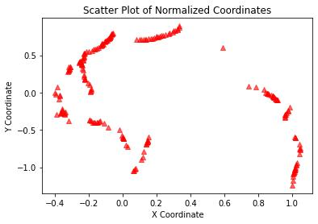

```python
# Normalise geo_x and geo_y values with StandardScaler method
#scaler = StandardScaler()
#scaler = MinMaxScaler()
scaler = RobustScaler()
coordinates = volcanoes_selected_gdf_clustering[['geo_x', 'geo_y']]
normalized_coordinates = scaler.fit_transform(coordinates)

# create two new columns geo_x_norm and geo_y_norm in the DataFrame
volcanoes_selected_gdf_clustering['geo_x_norm'] = [coord[0] for coord in normalized_coordinates]
volcanoes_selected_gdf_clustering['geo_y_norm'] = [coord[1] for coord in normalized_coordinates]

# draft results
plt.scatter(volcanoes_selected_gdf_clustering['geo_x_norm'], volcanoes_selected_gdf_clustering['geo_y_norm'], color="red", marker="^", alpha=0.6)
plt.xlabel('X Coordinate')
plt.ylabel('Y Coordinate')
plt.title('Scatter Plot of Normalized Coordinates')
plt.show()
```

### Dropping old columns

```python
# drop all unsed columns directly (in place)
volcanoes_selected_gdf_clustering.drop(columns=['geo_x', 'geo_y'], inplace=True)

# show results
display(volcanoes_selected_gdf_clustering)
print(volcanoes_selected_gdf_clustering.columns.tolist())
```

|  | Volcano_Number | Volcano_Name | geo_x_norm | geo_y_norm |
| --- | --- | --- | --- | --- |
| 0 | 241040 | Whakaari/White Island | 0.078733 | -1.017883 |
| 1 | 241050 | Okataina | 0.073062 | -1.030196 |
| 2 | 241080 | Tongariro | 0.065691 | -1.049531 |
| 3 | 241100 | Ruapehu | 0.065169 | -1.051909 |
| 4 | 242030 | Raoul Island | 0.120017 | -0.858386 |
| ... | ... | ... | ... | ... |
| 196 | 358041 | Chaiten | 1.006922 | -1.120636 |
| 197 | 358057 | Hudson, Cerro | 1.004238 | -1.179894 |
| 198 | 358060 | Lautaro | 0.999739 | -1.240193 |
| 199 | 284193 | South Sarigan Seamount | -0.185817 | 0.028033 |
| 200 | 242005 | Havre Seamount | 0.110639 | -0.893378 |

201 rows × 4 columns

```
['Volcano_Number', 'Volcano_Name', 'geo_x_norm', 'geo_y_norm']
```

## (Re-) Clustering

```python
# set columns used for clustering
cluster_columns = ['geo_x_norm', 'geo_y_norm']
```

```python
def plot_clusters(df, cluster_code):
    """
    Plots clusters on a 2D scatter plot.

    Parameters:
    - df: pandas.DataFrame, the dataframe containing the data.
    - cluster_col: str, column name for cluster labels.
    - cluster_code: str, name or ID of the clustering method/identifier.

    Returns:
    - None
    """

    # get unique cluster labels
    unique_clusters = df[cluster_code].unique()

    # Extract columns
    geo_x = df['geo_x']
    geo_y = df['geo_y']
    cluster_labels = df[cluster_code]

    # Create scatter plot
    scatter = plt.scatter(
        geo_x,
        geo_y,
        c=cluster_labels,
        cmap='gist_rainbow'
    )

    # Create legend handles for unique clusters
    unique_clusters = np.unique(cluster_labels)
    handles = [
        mpatches.Patch(color=scatter.cmap(scatter.norm(value)), label=f'Cluster {value}')
        for value in unique_clusters
    ]

    # Add legend
    plt.legend(handles=handles, title='Clusters', bbox_to_anchor=(1.05, 1), loc='upper left')

    # Add axis labels and title
    plt.xlabel('geo_x')
    plt.ylabel('geo_y')
    plt.title(f'Clusters for cluster_id = {cluster_code}')

    # Adjust layout and show plot
    plt.tight_layout()
    plt.show()
```

```python
def evaluate_silhouette_score(data, cluster_labels):
    """
    Computes and interprets the silhouette score for a clustering result.

    Parameters:
    - data (array-like): The dataset used for clustering (e.g., coordinates).
    - cluster_labels (array-like): Cluster labels assigned to each data point.

    Returns:
    - float: The silhouette score.
    - str: Interpretation of the clustering quality.
    """
    try:
        score = silhouette_score(data, cluster_labels)
    except:
        score = 0

    if score > 0.7:
        interpretation = "The clusters are well-defined and separated."
    elif score > 0.5:
        interpretation = "The clusters are fairly well-separated."
    elif score > 0.25:
        interpretation = "The clusters are weakly separated and may overlap."
    elif score == 0:
        interpretation = "Unable to determine the metrics."
    else:
        interpretation = "The clustering structure is poor."

    return score, interpretation
```

```python
def print_silhouette_metrics(df, cluster_code):
    """
    Prints the silhouette score and its interpretation for a given clustering result.

    Parameters:
    - df: pandas.DataFrame, the data used for clustering.
    - cluster_labels: array-like or pandas.Series, the cluster labels for the data.
    - cluster_code: str, the identifier for the clustering result.
    - evaluate_silhouette_score: function, a function that calculates the silhouette score and its interpretation.

    Returns:
    - None
    """
    # Calculate silhouette score and interpretation
    score, interpretation = evaluate_silhouette_score(df, cluster_code)

    # Print the results
    print(f"Silhouette Score for {cluster_code}: {score:.4f}, {interpretation}")
```

```python
def display_cluster_counts(df, cluster_code):
    """
    Generates and displays an ASCII table with cluster counts and totals.

    Parameters:
    - df: pandas.DataFrame, the data containing the clustering results.
    - cluster_code: str, the column name for cluster labels.

    Returns:
    - None
    """
    print("\n")

    # Generate the ASCII table and counts
    table, count, count_of_items = create_ascii_table(df, cluster_code)

    # Display the results
    print(table)
    print("\nTotal count:", count)
    print("Count of items:", count_of_items)
```

### Existing GVP clusters

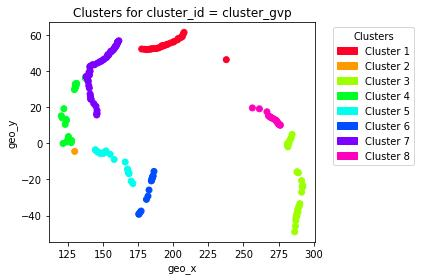

```
  cluster_gvp    Count  Percentage
-------------  -------  ------------
            7       58  28.86%
            3       32  15.92%
            4       27  13.43%
            1       27  13.43%
            5       21  10.45%
            8       20  9.95%
            6       15  7.46%
            2        1  0.50%

Total count: 201
Count of items: 8
```

```python
# set cluster code
cluster_code = 'cluster_gvp'

# get unique cluster labels
unique_clusters = volcanoes_selected_gdf_results[cluster_code].unique()

# plot results, show (some) metrics and cluster counts
plot_clusters(df=volcanoes_selected_gdf_results, cluster_code=cluster_code)
display_cluster_counts(volcanoes_selected_gdf_results, cluster_code)
```

### k-means

#### Elbow method

```
k=1, inertia=120.48
k=2, inertia=51.11
k=3, inertia=25.08
k=4, inertia=16.22
k=5, inertia=9.48
k=6, inertia=5.97
k=7, inertia=4.37
k=8, inertia=3.51
k=9, inertia=2.84
k=10, inertia=2.32
```

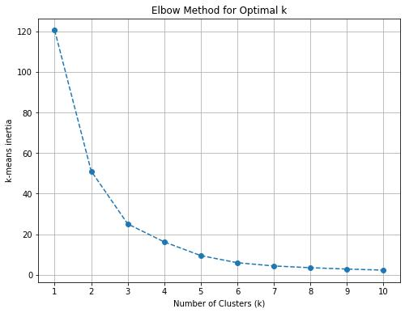

```python
# set cluster code
cluster_code = 'cluster_kmeans'

# list to store inertia values
inertia_values = []

# range of k values to evaluate
k_range = range(1, 11)

# perform k-means for each k and store inertia
for k in k_range:
    kmeans = KMeans(n_clusters=k, random_state=42)
    #kmeans.fit(X)
    kmeans.fit(volcanoes_selected_gdf_clustering[cluster_columns])
    inertia_values.append(kmeans.inertia_)
    print(f"k={k}, inertia={kmeans.inertia_:.2f}")

# simple plot the Elbow Method
plt.figure(figsize=(8, 6))
plt.plot(k_range, inertia_values, marker='o', linestyle='--')
plt.xticks(k_range)
plt.title("Elbow Method for Optimal k")
plt.xlabel("Number of Clusters (k)")
plt.ylabel("k-means inertia")
plt.grid(True)
plt.show()
```

For this case, k should be in the range of [2;5] and due to the nature of the original data with 8 regions, k = 5 is chosen.

#### Clustering

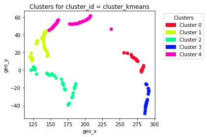

```
  cluster_kmeans    Count  Percentage
----------------  -------  ------------
               4       54  26.87%
               2       48  23.88%
               1       47  23.38%
               0       29  14.43%
               3       23  11.44%

Total count: 201
Count of items: 5
```

```python
# set cluster code
cluster_code = 'cluster_kmeans'

# set hyperparameters
n_clusters = 5
max_iter = 500
n_init = 20
init = "k-means++"

# k-means clustering
kmeans = KMeans(n_clusters=n_clusters,  max_iter=max_iter, n_init=n_init)
kmeans.fit(volcanoes_selected_gdf_clustering[cluster_columns])
clusters_kmeans = kmeans.labels_
volcanoes_selected_gdf_results[cluster_code] = clusters_kmeans

# plot results, show (some) metrics and cluster counts
plot_clusters(df=volcanoes_selected_gdf_results, cluster_code=cluster_code)
display_cluster_counts(volcanoes_selected_gdf_results, cluster_code)
```

### DBSCAN

#### Elbow plot (k-distance plot)

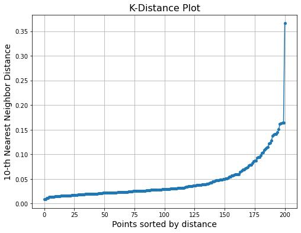

```python
from sklearn.neighbors import NearestNeighbors

# Define the number of neighbors
min_samples = 5

# compute the k-nearest neighbors
nbrs = NearestNeighbors(n_neighbors=min_samples).fit(volcanoes_selected_gdf_clustering[cluster_columns])
distances, indices = nbrs.kneighbors(volcanoes_selected_gdf_clustering[cluster_columns])

# sort the distances (take the k-th distance for each point)
# k-th nearest neighbor distance
k_distances = distances[:, -1]
k_distances = np.sort(k_distances)

# simple plot the k-distance graph
plt.figure(figsize=(8, 6))
plt.plot(k_distances, marker='o', linestyle='-', markersize=4)
plt.xlabel("Points sorted by distance", fontsize=14)
plt.ylabel(f"{k}-th Nearest Neighbor Distance", fontsize=14)
plt.title("K-Distance Plot", fontsize=16)
plt.grid()
plt.show()
```

The Elbow point is set to the visible break at c. [180;0.15], therefore eps = 0.15 with min_samples = 5.

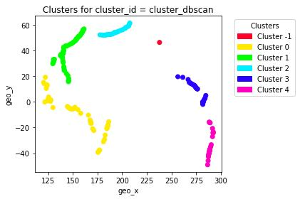

```
  cluster_dbscan    Count  Percentage
----------------  -------  ------------
               1       68  33.83%
               0       54  26.87%
               3       29  14.43%
               2       26  12.94%
               4       23  11.44%
              -1        1  0.50%

Total count: 201
Count of items: 6
```

```python
# set cluster code
cluster_code = 'cluster_dbscan'

# set hyperparameters
eps = 0.15
min_samples = 5
metric = 'euclidean'

# dbscan clustering
dbscan = DBSCAN(eps=eps, min_samples=min_samples, metric=metric)
clusters_dbscan = dbscan.fit_predict(volcanoes_selected_gdf_clustering[cluster_columns])
volcanoes_selected_gdf_results[cluster_code] = clusters_dbscan

# plot results, show (some) metrics and cluster counts
plot_clusters(df=volcanoes_selected_gdf_results, cluster_code=cluster_code)
display_cluster_counts(volcanoes_selected_gdf_results, cluster_code)
```

### GMM

#### AIC, BIC information criterion

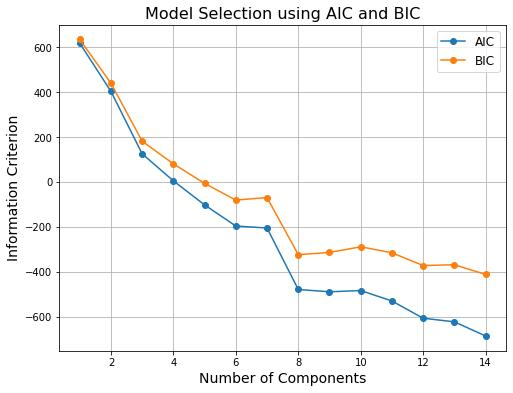

```python
import numpy as np
from sklearn.mixture import GaussianMixture
import matplotlib.pyplot as plt

# Test a range of components
n_components = np.arange(1, 15)
models = [GaussianMixture(n, covariance_type='full', random_state=42).fit(volcanoes_selected_gdf_clustering[cluster_columns]) for n in n_components]

# Compute AIC and BIC
aic = [model.aic(volcanoes_selected_gdf_clustering[cluster_columns]) for model in models]
bic = [model.bic(volcanoes_selected_gdf_clustering[cluster_columns]) for model in models]

# Plot AIC and BIC
plt.figure(figsize=(8, 6))
plt.plot(n_components, aic, label='AIC', marker='o')
plt.plot(n_components, bic, label='BIC', marker='o')
plt.xlabel('Number of Components', fontsize=14)
plt.ylabel('Information Criterion', fontsize=14)
plt.title('Model Selection using AIC and BIC', fontsize=16)
plt.legend(fontsize=12)
plt.grid()
plt.show()
```

#### Clustering

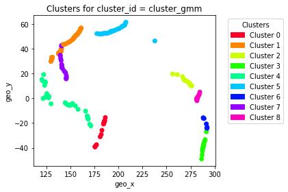

```
  cluster_gmm    Count  Percentage
-------------  -------  ------------
            1       48  23.88%
            4       39  19.40%
            5       27  13.43%
            7       20  9.95%
            2       20  9.95%
            3       16  7.96%
            0       15  7.46%
            8        9  4.48%
            6        7  3.48%

Total count: 201
Count of items: 9
```

```python
# set cluster code
cluster_code = 'cluster_gmm'

# set hyperparameters
n_components = 9
covariance_type='full' # diag, full, tied, sperical
max_iter = 500
init_params = 'kmeans'

# GMM Clustering
gmm = GaussianMixture(n_components=n_components, init_params=init_params, covariance_type=covariance_type, max_iter=max_iter)
gmm_clusters = gmm.fit_predict(volcanoes_selected_gdf_clustering[cluster_columns])
volcanoes_selected_gdf_results[cluster_code] = gmm_clusters

# plot results, show (some) metrics and cluster counts
plot_clusters(df=volcanoes_selected_gdf_results, cluster_code=cluster_code)
display_cluster_counts(volcanoes_selected_gdf_results, cluster_code)
```

### Ward (Agglomerative)

#### Elbow plot

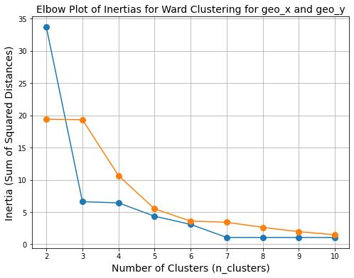

```python
def compute_inertia(X, labels):
    inertia = 0
    for cluster in np.unique(labels):
        cluster_points = X[labels == cluster]
        centroid = np.mean(cluster_points, axis=0)
        inertia += np.sum((cluster_points - centroid) ** 2)
    return inertia

# Test different numbers of clusters and compute inertia
n_clusters_range = range(2, 11)
inertias = []

for n_clusters in n_clusters_range:
    model = AgglomerativeClustering(n_clusters=n_clusters, linkage="ward")
    labels = model.fit_predict(volcanoes_selected_gdf_clustering[cluster_columns])
    inertia = compute_inertia(volcanoes_selected_gdf_clustering[cluster_columns], labels)
    inertias.append(inertia)

# Plot the Elbow Plot
plt.figure(figsize=(8, 6))
plt.plot(n_clusters_range, inertias, marker='o', linestyle='-', markersize=8)
plt.xlabel("Number of Clusters (n_clusters)", fontsize=14)
plt.ylabel("Inertia (Sum of Squared Distances)", fontsize=14)
plt.title("Elbow Plot of Inertias for Ward Clustering for geo_x and geo_y", fontsize=14)
plt.grid()
plt.show()
```

#### Dendrogram

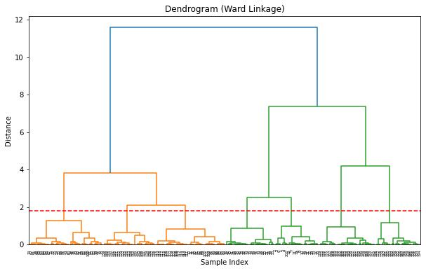

```python
from scipy.cluster.hierarchy import dendrogram, linkage

# Compute the linkage matrix
linkage_matrix = linkage(volcanoes_selected_gdf_clustering[cluster_columns], method="ward")

# Plot the dendrogram
plt.figure(figsize=(10, 6))
dendrogram(linkage_matrix, truncate_mode="level")
plt.axhline(y=1.8, color='red', linestyle='--', label='Distance = 1.8')
plt.title("Dendrogram (Ward Linkage)")
plt.xlabel("Sample Index")
plt.ylabel("Distance")
plt.show()
```

Elbow points might be in the range [3;7], which the dendogram also suggests. This leads to n_clusters = 7, which is the same as the original number of cluster for GVP without the cluster with only 1 member.

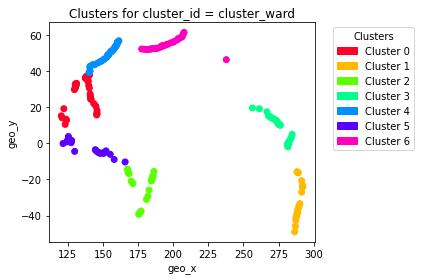

```
  cluster_ward    Count  Percentage
--------------  -------  ------------
             0       38  18.91%
             4       36  17.91%
             3       29  14.43%
             6       27  13.43%
             5       25  12.44%
             2       23  11.44%
             1       23  11.44%

Total count: 201
Count of items: 7
```

```python
# set cluster code
cluster_code = 'cluster_ward'

# set hyperparameters
n_clusters = 7
linkage = 'ward'
affinity = 'euclidean'

# Ward clustering
ward_clustering = AgglomerativeClustering(n_clusters=n_clusters, linkage=linkage, affinity=affinity)
ward_clusters = ward_clustering.fit_predict(volcanoes_selected_gdf_clustering[cluster_columns])
volcanoes_selected_gdf_results[cluster_code] = ward_clusters

# plot results, show (some) metrics and cluster counts
plot_clusters(df=volcanoes_selected_gdf_results, cluster_code=cluster_code)
display_cluster_counts(volcanoes_selected_gdf_results, cluster_code)
```

### Spectral

#### Maximum Silhouette score

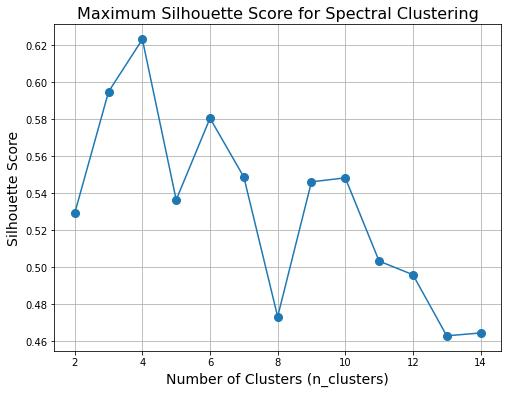

```python
# test different numbers of clusters and compute the silhouette score
n_clusters_range = range(2, 15)
silhouette_scores = []

for n_clusters in n_clusters_range:
    # apply Spectral Clustering
    model = SpectralClustering(n_clusters=n_clusters, affinity='rbf', random_state=42, assign_labels='kmeans')
    labels = model.fit_predict(volcanoes_selected_gdf_clustering[cluster_columns])

    # compute Silhouette Score
    score = silhouette_score(volcanoes_selected_gdf_clustering[cluster_columns], labels)
    silhouette_scores.append(score)

# imply plot the Silhouette Score
plt.figure(figsize=(8, 6))
plt.plot(n_clusters_range, silhouette_scores, marker='o', linestyle='-', markersize=8)
plt.xlabel("Number of Clusters (n_clusters)", fontsize=14)
plt.ylabel("Silhouette Score", fontsize=14)
plt.title("Maximum Silhouette Score for Spectral Clustering", fontsize=16)
plt.grid()
plt.show()
```

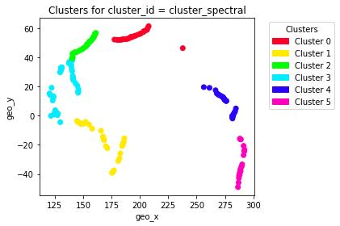

```
  cluster_spectral    Count  Percentage
------------------  -------  ------------
                 3       50  24.88%
                 1       36  17.91%
                 2       36  17.91%
                 4       29  14.43%
                 0       27  13.43%
                 5       23  11.44%

Total count: 201
Count of items: 6
```

```python
# set cluster code
cluster_code = 'cluster_spectral'

# set hyperparameters
n_clusters = 6
affinity='nearest_neighbors'

# Spectral Clustering
spectral_clustering = SpectralClustering(n_clusters=n_clusters, affinity=affinity)
spectral_clusters = spectral_clustering.fit_predict(volcanoes_selected_gdf_clustering[cluster_columns])
volcanoes_selected_gdf_results[cluster_code] = spectral_clusters

# plot results, show (some) metrics and cluster counts
plot_clusters(df=volcanoes_selected_gdf_results, cluster_code=cluster_code)
display_cluster_counts(volcanoes_selected_gdf_results, cluster_code)
```

### BIRCH

#### Elbow plot with Silhouette Score

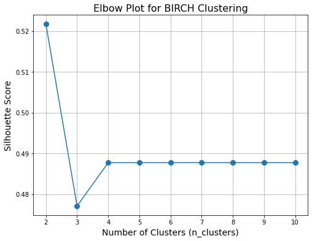

```python
# Test different numbers of clusters
n_clusters_range = range(2, 11)
silhouette_scores = []

for n_clusters in n_clusters_range:
    # Apply BIRCH clustering
    model = Birch(n_clusters=n_clusters, threshold=0.5, branching_factor=50)
    labels = model.fit_predict(volcanoes_selected_gdf_clustering[cluster_columns])

    # Compute Silhouette Score
    score = silhouette_score(volcanoes_selected_gdf_clustering[cluster_columns], labels)
    silhouette_scores.append(score)

# Plot the Elbow Plot
plt.figure(figsize=(8, 6))
plt.plot(n_clusters_range, silhouette_scores, marker='o', linestyle='-', markersize=8)
plt.xlabel("Number of Clusters (n_clusters)", fontsize=14)
plt.ylabel("Silhouette Score", fontsize=14)
plt.title("Elbow Plot for BIRCH Clustering", fontsize=16)
plt.grid()
plt.show()
```

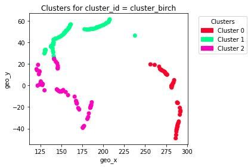

```
  cluster_birch    Count  Percentage
---------------  -------  ------------
              1       86  42.79%
              2       63  31.34%
              0       52  25.87%

Total count: 201
Count of items: 3
```

```python
# set cluster code
cluster_code = 'cluster_birch'

# set hyperparameters
threshold = 0.47

# Perform ENRC clustering
data = np.array(volcanoes_selected_gdf_clustering[cluster_columns])
birch_clustering = Birch(threshold=threshold)
birch_clusters = birch_clustering.fit_predict(data)
volcanoes_selected_gdf_results[cluster_code] = birch_clusters

# plot results, show (some) metrics and cluster counts
plot_clusters(df=volcanoes_selected_gdf_results, cluster_code=cluster_code)
display_cluster_counts(volcanoes_selected_gdf_results, cluster_code)
```

### IDEC

For IDEC the original number of regions n = 8 is used.

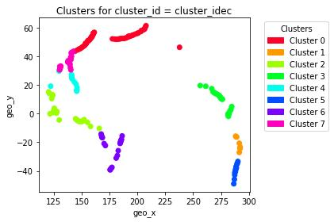

```
  cluster_idec    Count  Percentage
--------------  -------  ------------
             0       55  27.36%
             2       30  14.93%
             3       29  14.43%
             7       28  13.93%
             6       23  11.44%
             5       15  7.46%
             4       13  6.47%
             1        8  3.98%

Total count: 201
Count of items: 8
```

```python
# set cluster code
cluster_code = 'cluster_idec'

# set hyperparameters
n_clusters = 8
embedding_size = 2

# Perform ENRC clustering
data = np.array(volcanoes_selected_gdf_clustering[cluster_columns])
idec_clustering = IDEC(n_clusters=n_clusters, embedding_size=embedding_size)
idec_clusters = idec_clustering.fit_predict(data)
volcanoes_selected_gdf_results[cluster_code] = idec_clusters

# plot results, show (some) metrics and cluster counts
plot_clusters(df=volcanoes_selected_gdf_results, cluster_code=cluster_code)
display_cluster_counts(volcanoes_selected_gdf_results, cluster_code)
```

### MultiDensityDBSCAN

#### Max Silhouette Score

[figure not shown]

```python
# Test different numbers of clusters
k_range = range(2, 15)
silhouette_scores = []

for k in k_range:
    # Apply MultiDensityDBSCAN clustering
    model = MultiDensityDBSCAN(k=k, var=8, min_cluster_size=5)
    labels = model.fit_predict(volcanoes_selected_gdf_clustering[cluster_columns])

    # Compute Silhouette Score
    score = silhouette_score(volcanoes_selected_gdf_clustering[cluster_columns], labels)
    silhouette_scores.append(score)

# Plot the Elbow Plot
plt.figure(figsize=(8, 6))
plt.plot(k_range, silhouette_scores, marker='o', linestyle='-', markersize=8)
plt.xlabel("Number of Clusters (n_clusters)", fontsize=14)
plt.ylabel("Silhouette Score", fontsize=14)
plt.title("Elbow Plot for BIRCH Clustering", fontsize=16)
plt.grid()
plt.show()
```

The previous plot suggests a range of [4;8] for k with a maximum at k = 4. To have a good spatial distribution, k = 8 is chosen.

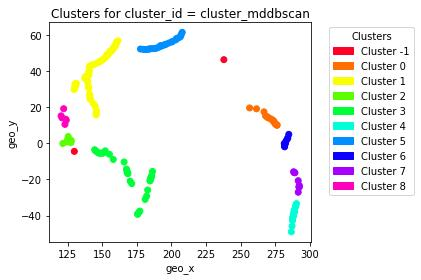

```
  cluster_mddbscan    Count  Percentage
------------------  -------  ------------
                 1       68  33.83%
                 3       36  17.91%
                 5       26  12.94%
                 0       20  9.95%
                 4       15  7.46%
                 2       11  5.47%
                 6        9  4.48%
                 7        8  3.98%
                 8        6  2.99%
                -1        2  1.00%

Total count: 201
Count of items: 10
```

```python
# set cluster code
cluster_code = 'cluster_mddbscan'

# set hyperparameters
k=8
var=8
min_cluster_size=5

# Perform MultiDensityDBSCAN clustering
data = np.array(volcanoes_selected_gdf_clustering[cluster_columns])
mddbscan_clustering = MultiDensityDBSCAN(k=k, var=var, min_cluster_size=min_cluster_size)
mddbscan_clusters = mddbscan_clustering.fit_predict(data)
volcanoes_selected_gdf_results[cluster_code] = mddbscan_clusters

# plot results, show (some) metrics and cluster counts
plot_clusters(df=volcanoes_selected_gdf_results, cluster_code=cluster_code)
display_cluster_counts(volcanoes_selected_gdf_results, cluster_code)
```

## Evaluation

```python
# def evaluate_silhouette_score(data, cluster_labels):
#     """
#     Computes and interprets the silhouette score for a clustering result.

#     Parameters:
#     - data (array-like): The dataset used for clustering (e.g., coordinates).
#     - cluster_labels (array-like): Cluster labels assigned to each data point.

#     Returns:
#     - float: The silhouette score.
#     - str: Interpretation of the clustering quality.
#     """
#     try:
#         score = silhouette_score(data, cluster_labels)
#     except:
#         score = 0

#     if score > 0.7:
#         interpretation = "The clusters are well-defined and separated."
#     elif score > 0.5:
#         interpretation = "The clusters are fairly well-separated."
#     elif score > 0.25:
#         interpretation = "The clusters are weakly separated and may overlap."
#     elif score == 0:
#         interpretation = "Unable to determine the metrics."
#     else:
#         interpretation = "The clustering structure is poor."

#     return score, interpretation
```

```python
def calculate_cluster_metrics(df_features, df_results, cluster_code):

    # get features and labels
    labels = df_results[cluster_code].values
    features = df_features

    # Calculate Silhouette Index (requires at least 2 clusters)
    try:
        silhouette = silhouette_score(features, labels) if len(np.unique(labels)) > 1 else None
    except:
        silhouette = np.nan

    # Calculate Calinski-Harabasz Index
    try:
        calinski_harabasz = calinski_harabasz_score(features, labels)
    except:
        calinski_harabasz = np.nan

    # Calculate Davies-Bouldin Index
    try:
        davies_bouldin = davies_bouldin_score(features, labels)
    except:
        davies_bouldin = np.nan

    # Custom function to calculate Dunn Index
    def dunn_index(features, labels):
        try:
            unique_labels = np.unique(labels)
            inter_cluster_distances = []
            intra_cluster_distances = []

            for i in unique_labels:
                cluster_i = features[labels == i]
                intra_cluster_distances.append(np.max(cdist(cluster_i, cluster_i)))

                for j in unique_labels:
                    if i != j:
                        cluster_j = features[labels == j]
                        inter_cluster_distances.append(np.min(cdist(cluster_i, cluster_j)))

            # Dunn Index: min(inter-cluster distance) / max(intra-cluster distance)
            if intra_cluster_distances:
                return np.min(inter_cluster_distances) / np.max(intra_cluster_distances)
            else:
                return np.nan

        except:
                return np.nan
    dunn = dunn_index(features, labels)

    # Return metrics in a dictionary
    metrics = {
        "(SI) Silhouette Index [max=1]": silhouette,
        "(CHI) Calinski-Harabasz Index [max]": calinski_harabasz,
        "(DBI) Davies-Bouldin Index [min=0]": davies_bouldin,
        "(DI) Dunn Index [max]": dunn,
    }

    return metrics
```

```python
# show the results table
display(volcanoes_selected_gdf_results)
```

|  | Volcano_Number | Volcano_Name | geo_x | geo_y | cluster_gvp | cluster_kmeans | cluster_dbscan | cluster_gmm | cluster_ward | cluster_spectral | cluster_birch | cluster_idec | cluster_mddbscan |
| --- | --- | --- | --- | --- | --- | --- | --- | --- | --- | --- | --- | --- | --- |
| 0 | 241040 | Whakaari/White Island | 177.1800 | -37.5200 | 6 | 2 | 0 | 0 | 2 | 1 | 2 | 6 | 3 |
| 1 | 241050 | Okataina | 176.5069 | -38.1569 | 6 | 2 | 0 | 0 | 2 | 1 | 2 | 6 | 3 |
| 2 | 241080 | Tongariro | 175.6320 | -39.1570 | 6 | 2 | 0 | 0 | 2 | 1 | 2 | 6 | 3 |
| 3 | 241100 | Ruapehu | 175.5700 | -39.2800 | 6 | 2 | 0 | 0 | 2 | 1 | 2 | 6 | 3 |
| 4 | 242030 | Raoul Island | 182.0800 | -29.2700 | 6 | 2 | 0 | 0 | 2 | 1 | 2 | 6 | 3 |
| ... | ... | ... | ... | ... | ... | ... | ... | ... | ... | ... | ... | ... | ... |
| 196 | 358041 | Chaiten | 287.3486 | -42.8349 | 3 | 3 | 4 | 3 | 1 | 5 | 0 | 5 | 4 |
| 197 | 358057 | Hudson, Cerro | 287.0300 | -45.9000 | 3 | 3 | 4 | 3 | 1 | 5 | 0 | 5 | 4 |
| 198 | 358060 | Lautaro | 286.4960 | -49.0190 | 3 | 3 | 4 | 3 | 1 | 5 | 0 | 5 | 4 |
| 199 | 284193 | South Sarigan Seamount | 145.7800 | 16.5800 | 7 | 1 | 1 | 7 | 0 | 3 | 2 | 4 | 1 |
| 200 | 242005 | Havre Seamount | 180.9670 | -31.0800 | 6 | 2 | 0 | 0 | 2 | 1 | 2 | 6 | 3 |

201 rows × 13 columns

### Calculate internal cluster metrics

```python
# create an empty DataFrame to store results
all_metrics_df = pd.DataFrame()

# loop over columns starting with "cluster_"
for cluster_code in volcanoes_selected_gdf_results.columns:
    if cluster_code.startswith("cluster_"):
        print(f"Processing: {cluster_code}")

        # calculate metrics
        metrics = calculate_cluster_metrics(df_features=volcanoes_selected_gdf_clustering[cluster_columns],
                                            df_results=volcanoes_selected_gdf_results, cluster_code=cluster_code)

        # convert metrics dictionary to DataFrame
        metrics_df = pd.DataFrame(list(metrics.items()), columns=["metric", cluster_code])

        # Merge or concatenate metrics for all cluster columns
        if all_metrics_df.empty:
            all_metrics_df = metrics_df
        else:
            all_metrics_df = pd.merge(all_metrics_df, metrics_df, on="metric", how="outer")
```

```
Processing: cluster_gvp
Processing: cluster_kmeans
Processing: cluster_dbscan
Processing: cluster_gmm
Processing: cluster_ward
Processing: cluster_spectral
Processing: cluster_birch
Processing: cluster_idec
Processing: cluster_mddbscan
```

```python
# show the metrics
pd.options.display.float_format = "{:.3f}".format
display(all_metrics_df)
pd.reset_option("display.float_format")
```

|  | metric | cluster_gvp | cluster_kmeans | cluster_dbscan | cluster_gmm | cluster_ward | cluster_spectral | cluster_birch | cluster_idec | cluster_mddbscan |
| --- | --- | --- | --- | --- | --- | --- | --- | --- | --- | --- |
| 0 | (SI) Silhouette Index [max=1] | 0.319 | 0.600 | 0.551 | 0.452 | 0.608 | 0.564 | 0.582 | 0.554 | 0.474 |
| 1 | (CHI) Calinski-Harabasz Index [max] | 299.463 | 573.962 | 374.480 | 487.982 | 839.310 | 559.727 | 365.778 | 669.282 | 338.815 |
| 2 | (DBI) Davies-Bouldin Index [min=0] | 0.695 | 0.501 | 0.448 | 0.584 | 0.487 | 0.497 | 0.642 | 0.490 | 1.120 |
| 3 | (DI) Dunn Index [max] | 0.008 | 0.020 | 0.129 | 0.020 | 0.041 | 0.032 | 0.020 | 0.021 | 0.072 |

```python
# Function to apply styling
def highlight_extremes(row):
    """
    Highlight the highest value in green and the lowest value in red for each row.
    """
    is_max = row == row.max()
    is_min = row == row.min()
    return ['background-color: lightgreen' if v else 'background-color: lightcoral' if w else '' for v, w in zip(is_max, is_min)]

# Apply the styling function to the numerical columns of the DataFrame
styled_df = all_metrics_df.style.apply(highlight_extremes, axis=1, subset=all_metrics_df.columns[1:])

# Display the styled DataFrame
display(styled_df)
```

|  | metric | cluster_gvp | cluster_kmeans | cluster_dbscan | cluster_gmm | cluster_ward | cluster_spectral | cluster_birch | cluster_idec | cluster_mddbscan |
| --- | --- | --- | --- | --- | --- | --- | --- | --- | --- | --- |
| 0 | (SI) Silhouette Index [max=1] | 0.318658 | 0.599818 | 0.551143 | 0.452461 | 0.607565 | 0.563859 | 0.582059 | 0.554316 | 0.473778 |
| 1 | (CHI) Calinski-Harabasz Index [max] | 299.462545 | 573.962341 | 374.479575 | 487.982052 | 839.309702 | 559.726925 | 365.777873 | 669.282027 | 338.814634 |
| 2 | (DBI) Davies-Bouldin Index [min=0] | 0.694751 | 0.500916 | 0.447865 | 0.583593 | 0.487453 | 0.497236 | 0.641679 | 0.490290 | 1.119702 |
| 3 | (DI) Dunn Index [max] | 0.008262 | 0.020029 | 0.129213 | 0.019858 | 0.041115 | 0.032157 | 0.019681 | 0.020885 | 0.071732 |

```python
# Dropping the "metric" column to rank only numeric values
ranked_df = all_metrics_df.copy()
ranked_df.iloc[:, 1:] = all_metrics_df.iloc[:, 1:].apply(pd.to_numeric, errors='coerce')

# Apply the specified ranking logic
ranked_df.iloc[0, 1:] = ranked_df.iloc[0, 1:].rank(method='min')  # Increasing
ranked_df.iloc[1, 1:] = ranked_df.iloc[1, 1:].rank(method='min')  # Increasing
ranked_df.iloc[2, 1:] = ranked_df.iloc[2, 1:].rank(method='min', ascending=False)  # Decreasing
ranked_df.iloc[3, 1:] = ranked_df.iloc[3, 1:].rank(method='min')  # Increasing

# Adding back the "metric" column
ranked_df["metric"] = all_metrics_df["metric"]

# Calculate the mean rank for each column (ignoring NaN values)
mean_rank = ranked_df.iloc[:, 1:].mean()

# Add the "Mean rank" row to the dataframe
ranked_df.loc[len(ranked_df)] = ["Mean rank"] + mean_rank.tolist()

# Apply the styling function to the numerical columns of the DataFrame
styled_df = ranked_df.style.apply(highlight_extremes, axis=1, subset=all_metrics_df.columns[1:])

# Display the styled DataFrame
display(styled_df)
```

|  | metric | cluster_gvp | cluster_kmeans | cluster_dbscan | cluster_gmm | cluster_ward | cluster_spectral | cluster_birch | cluster_idec | cluster_mddbscan |
| --- | --- | --- | --- | --- | --- | --- | --- | --- | --- | --- |
| 0 | (SI) Silhouette Index [max=1] | 1.000000 | 8.000000 | 4.000000 | 2.000000 | 9.000000 | 6.000000 | 7.000000 | 5.000000 | 3.000000 |
| 1 | (CHI) Calinski-Harabasz Index [max] | 1.000000 | 7.000000 | 4.000000 | 5.000000 | 9.000000 | 6.000000 | 3.000000 | 8.000000 | 2.000000 |
| 2 | (DBI) Davies-Bouldin Index [min=0] | 2.000000 | 5.000000 | 9.000000 | 4.000000 | 8.000000 | 6.000000 | 3.000000 | 7.000000 | 1.000000 |
| 3 | (DI) Dunn Index [max] | 1.000000 | 4.000000 | 9.000000 | 3.000000 | 7.000000 | 6.000000 | 2.000000 | 5.000000 | 8.000000 |
| 4 | Mean rank | 1.250000 | 6.000000 | 6.500000 | 3.500000 | 8.250000 | 6.000000 | 3.750000 | 6.250000 | 3.500000 |

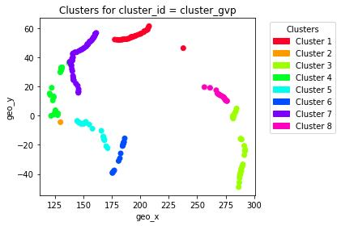

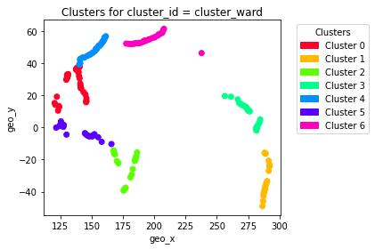

```python
# get an idea of the results

cluster_code = 'cluster_gvp'
plot_clusters(df=volcanoes_selected_gdf_results, cluster_code=cluster_code)

cluster_code = 'cluster_ward'
plot_clusters(df=volcanoes_selected_gdf_results, cluster_code=cluster_code)
```

### Compare clusters with cluster_gvp by external cluster metrics

```python
# Initialize an empty list to collect data for the DataFrame
results = []

# Loop over columns starting with "cluster_"
for cluster_code in volcanoes_selected_gdf_results.columns:
    if cluster_code.startswith("cluster_") and cluster_code != 'cluster_gvp':
        print(f"Processing: {cluster_code}")

        y_true = volcanoes_selected_gdf_results['cluster_gvp']
        y_pred = volcanoes_selected_gdf_results[cluster_code]

        # Calculate metrics
        jaccard_multi = jaccard_score(y_true, y_pred, average='weighted')
        rand_score = adjusted_rand_score(y_true, y_pred)
        fm_score = fowlkes_mallows_score(y_true, y_pred)

        # Append metrics as rows for this cluster_code
        results.append(["Jaccard Score [max=1]", cluster_code, jaccard_multi])
        results.append(["Rand Score [max=1]", cluster_code, rand_score])
        results.append(["Fowlkes-Mallows Score [max=1]", cluster_code, fm_score])

# Create a DataFrame from the results list
all_external_metrics_df = pd.DataFrame(results, columns=["Metrics", "Cluster", "Value"])

# Pivot the DataFrame so that "Cluster" columns are pivoted out
all_external_metrics_df = all_external_metrics_df.pivot(index="Metrics", columns="Cluster", values="Value")

# Reset the index for better readability
all_external_metrics_df = all_external_metrics_df.reset_index()

# Display the final DataFrame
display(all_external_metrics_df)
```

```
Processing: cluster_kmeans
Processing: cluster_dbscan
Processing: cluster_gmm
Processing: cluster_ward
Processing: cluster_spectral
Processing: cluster_birch
Processing: cluster_idec
Processing: cluster_mddbscan
```

| Cluster | Metrics | cluster_birch | cluster_dbscan | cluster_gmm | cluster_idec | cluster_kmeans | cluster_mddbscan | cluster_spectral | cluster_ward |
| --- | --- | --- | --- | --- | --- | --- | --- | --- | --- |
| 0 | Fowlkes-Mallows Score [max=1] | 0.569036 | 0.744093 | 0.677496 | 0.515849 | 0.562350 | 0.789187 | 0.688216 | 0.666233 |
| 1 | Jaccard Score [max=1] | 0.042252 | 0.027555 | 0.225708 | 0.165290 | 0.114532 | 0.000000 | 0.000000 | 0.068712 |
| 2 | Rand Score [max=1] | 0.398083 | 0.669385 | 0.616348 | 0.421892 | 0.456060 | 0.743781 | 0.624027 | 0.603023 |

```python
# Function to apply styling
def highlight_extremes(row):
    """
    Highlight the highest value in green and the lowest value in red for each row.
    """
    is_max = row == row.max()
    is_min = row == row.min()
    return ['background-color: lightgreen' if v else 'background-color: lightcoral' if w else '' for v, w in zip(is_max, is_min)]

# Apply the styling function to the numerical columns of the DataFrame
styled_df = all_external_metrics_df.style.apply(highlight_extremes, axis=1, subset=all_external_metrics_df.columns[1:])

# Display the styled DataFrame
display(styled_df)
```

| Cluster | Metrics | cluster_birch | cluster_dbscan | cluster_gmm | cluster_idec | cluster_kmeans | cluster_mddbscan | cluster_spectral | cluster_ward |
| --- | --- | --- | --- | --- | --- | --- | --- | --- | --- |
| 0 | Fowlkes-Mallows Score [max=1] | 0.569036 | 0.744093 | 0.677496 | 0.515849 | 0.562350 | 0.789187 | 0.688216 | 0.666233 |
| 1 | Jaccard Score [max=1] | 0.042252 | 0.027555 | 0.225708 | 0.165290 | 0.114532 | 0.000000 | 0.000000 | 0.068712 |
| 2 | Rand Score [max=1] | 0.398083 | 0.669385 | 0.616348 | 0.421892 | 0.456060 | 0.743781 | 0.624027 | 0.603023 |

```python
# Dropping the "metric" column to rank only numeric values
ranked_df = all_external_metrics_df.copy()
ranked_df.iloc[:, 1:] = all_external_metrics_df.iloc[:, 1:].apply(pd.to_numeric, errors='coerce')

# Apply the specified ranking logic
ranked_df.iloc[0, 1:] = ranked_df.iloc[0, 1:].rank(method='min')
ranked_df.iloc[1, 1:] = ranked_df.iloc[1, 1:].rank(method='min')
ranked_df.iloc[2, 1:] = ranked_df.iloc[2, 1:].rank(method='min')

# Calculate the mean rank for each column (ignoring NaN values)
mean_rank = ranked_df.iloc[:, 1:].mean()

# Add the "Mean rank" row to the dataframe
ranked_df.loc[len(ranked_df)] = ["Mean rank"] + mean_rank.tolist()

# Apply the styling function to the numerical columns of the DataFrame
styled_df = ranked_df.style.apply(highlight_extremes, axis=1, subset=all_external_metrics_df.columns[1:])

# Display the styled DataFrame
display(styled_df)
```

| Cluster | Metrics | cluster_birch | cluster_dbscan | cluster_gmm | cluster_idec | cluster_kmeans | cluster_mddbscan | cluster_spectral | cluster_ward |
| --- | --- | --- | --- | --- | --- | --- | --- | --- | --- |
| 0 | Fowlkes-Mallows Score [max=1] | 3.000000 | 7.000000 | 5.000000 | 1.000000 | 2.000000 | 8.000000 | 6.000000 | 4.000000 |
| 1 | Jaccard Score [max=1] | 4.000000 | 3.000000 | 8.000000 | 7.000000 | 6.000000 | 1.000000 | 1.000000 | 5.000000 |
| 2 | Rand Score [max=1] | 1.000000 | 7.000000 | 5.000000 | 2.000000 | 3.000000 | 8.000000 | 6.000000 | 4.000000 |
| 3 | Mean rank | 2.666667 | 5.666667 | 6.000000 | 3.333333 | 3.666667 | 5.666667 | 4.333333 | 4.333333 |

## Creating datasets and timeseries

The chosen cluster method is WARD.

```python
volcanoes_selected_gdf
```

|  | Volcano_Number | geo_x | geo_y | Volcano_Name | Primary_Volcano_Type | Country | Region | Latitude | Longitude | Elevation | Tectonic_Setting | Evidence_Category | Major_Rock_Type | Erupting | Last_Activity_Year | geometry |
| --- | --- | --- | --- | --- | --- | --- | --- | --- | --- | --- | --- | --- | --- | --- | --- | --- |
| 0 | 241040 | 177.1800 | -37.5200 | Whakaari/White Island | Stratovolcano(es) | New Zealand | Tonga-Kermadec Volcanic Regions | -37.5200 | 177.1800 | 294 | Subduction zone / Continental crust (> 25 km) | Eruption Observed | Andesite / Basaltic Andesite | True | 2019 | POINT (177.18000 -37.52000) |
| 1 | 241050 | 176.5069 | -38.1569 | Okataina | Lava dome(s) | New Zealand | Tonga-Kermadec Volcanic Regions | -38.1569 | 176.5069 | 1111 | Subduction zone / Continental crust (> 25 km) | Eruption Observed | Rhyolite | True | 1981 | POINT (176.50690 -38.15690) |
| 2 | 241080 | 175.6320 | -39.1570 | Tongariro | Stratovolcano(es) | New Zealand | Tonga-Kermadec Volcanic Regions | -39.1570 | 175.6320 | 1978 | Subduction zone / Continental crust (> 25 km) | Eruption Observed | Andesite / Basaltic Andesite | True | 2012 | POINT (175.63200 -39.15700) |
| 3 | 241100 | 175.5700 | -39.2800 | Ruapehu | Stratovolcano(es) | New Zealand | Tonga-Kermadec Volcanic Regions | -39.2800 | 175.5700 | 2797 | Subduction zone / Continental crust (> 25 km) | Eruption Observed | Andesite / Basaltic Andesite | True | 2007 | POINT (175.57000 -39.28000) |
| 4 | 242030 | 182.0800 | -29.2700 | Raoul Island | Stratovolcano(es) | New Zealand | Tonga-Kermadec Volcanic Regions | -29.2700 | -177.9200 | 516 | Subduction zone / Oceanic crust (< 15 km) | Eruption Observed | Andesite / Basaltic Andesite | True | 2006 | POINT (-177.92000 -29.27000) |
| ... | ... | ... | ... | ... | ... | ... | ... | ... | ... | ... | ... | ... | ... | ... | ... | ... |
| 196 | 358041 | 287.3486 | -42.8349 | Chaiten | Caldera | Chile | South America Volcanic Regions | -42.8349 | -72.6514 | 1122 | Subduction zone / Continental crust (> 25 km) | Eruption Observed | Rhyolite | True | 2011 | POINT (-72.65140 -42.83490) |
| 197 | 358057 | 287.0300 | -45.9000 | Hudson, Cerro | Stratovolcano(es) | Chile | South America Volcanic Regions | -45.9000 | -72.9700 | 1905 | Subduction zone / Continental crust (> 25 km) | Eruption Observed | Basalt / Picro-Basalt | True | 2011 | POINT (-72.97000 -45.90000) |
| 198 | 358060 | 286.4960 | -49.0190 | Lautaro | Stratovolcano(es) | Chile | South America Volcanic Regions | -49.0190 | -73.5040 | 3542 | Subduction zone / Continental crust (> 25 km) | Eruption Observed | Dacite | True | 1979 | POINT (-73.50400 -49.01900) |
| 199 | 284193 | 145.7800 | 16.5800 | South Sarigan Seamount | Stratovolcano(es) | United States | Northwest Pacific Volcanic Regions | 16.5800 | 145.7800 | -184 | Subduction zone / Crustal thickness unknown | Eruption Observed | unknown | True | 2010 | POINT (145.78000 16.58000) |
| 200 | 242005 | 180.9670 | -31.0800 | Havre Seamount | Stratovolcano(es) | New Zealand | Tonga-Kermadec Volcanic Regions | -31.0800 | -179.0330 | -897 | Subduction zone / Oceanic crust (< 15 km) | Eruption Observed | unknown | True | 2012 | POINT (-179.03300 -31.08000) |

201 rows × 16 columns

```
========================================================================================================================
ID 0
region_name = Cluster_0
Number of cluster points = 38
Number of filtered volcanoes = 38
```

```
2025-01-26 21:08:31,359 - INFO - 253_spatial_operations_gvp_reclustering.ipynb: Number of rows is EQUAL. Cluster (region) Cluster_0 has 38 vocanoes.
```

```
Number of filtered eruptions = 219
```

```
2025-01-26 21:08:31,865 - INFO - 253_spatial_operations_gvp_reclustering.ipynb: Set data directory for saving to './data/scope/reclustered_1000/cluster_Cluster_0'.
```

```
Earthquakes selected: 12682
```

```
2025-01-26 21:08:32,757 - INFO - 253_spatial_operations_gvp_reclustering.ipynb: Saving 25_Buffered_Earthquakes.png to './data/scope/reclustered_1000/cluster_Cluster_0'.
```

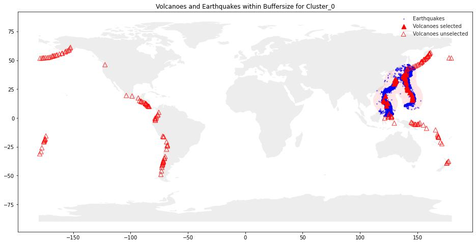

```
2025-01-26 21:08:33,102 - INFO - save_dataset: Data saved successfully to 'data/scope/reclustered_1000/cluster_Cluster_0/earthquakes_spatially_selected_250126-210832.csv'.
2025-01-26 21:08:33,327 - INFO - save_dataset: Data saved successfully to 'data/scope/reclustered_1000/cluster_Cluster_0/earthquakes_spatially_selected.csv'.
2025-01-26 21:08:33,332 - INFO - save_dataset: Data saved successfully to 'data/scope/reclustered_1000/cluster_Cluster_0/volcanoes_spatially_selected_250126-210833.csv'.
2025-01-26 21:08:33,335 - INFO - save_dataset: Data saved successfully to 'data/scope/reclustered_1000/cluster_Cluster_0/volcanoes_spatially_selected.csv'.
2025-01-26 21:08:33,339 - INFO - save_dataset: Data saved successfully to 'data/scope/reclustered_1000/cluster_Cluster_0/eruptions_spatially_selected_250126-210833.csv'.
2025-01-26 21:08:33,344 - INFO - save_dataset: Data saved successfully to 'data/scope/reclustered_1000/cluster_Cluster_0/eruptions_spatially_selected.csv'.
```

```
========================================================================================================================
ID 1
region_name = Cluster_1
Number of cluster points = 23
Number of filtered volcanoes = 23
```

```
2025-01-26 21:08:33,849 - INFO - 253_spatial_operations_gvp_reclustering.ipynb: Number of rows is EQUAL. Cluster (region) Cluster_1 has 23 vocanoes.
```

```
Number of filtered eruptions = 107
```

```
2025-01-26 21:08:34,354 - INFO - 253_spatial_operations_gvp_reclustering.ipynb: Set data directory for saving to './data/scope/reclustered_1000/cluster_Cluster_1'.
```

```
Earthquakes selected: 4744
```

```
2025-01-26 21:08:34,902 - INFO - 253_spatial_operations_gvp_reclustering.ipynb: Saving 25_Buffered_Earthquakes.png to './data/scope/reclustered_1000/cluster_Cluster_1'.
```

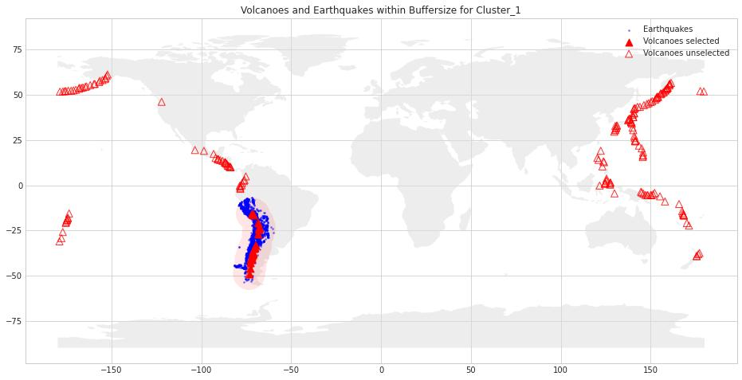

```
2025-01-26 21:08:35,081 - INFO - save_dataset: Data saved successfully to 'data/scope/reclustered_1000/cluster_Cluster_1/earthquakes_spatially_selected_250126-210834.csv'.
2025-01-26 21:08:35,164 - INFO - save_dataset: Data saved successfully to 'data/scope/reclustered_1000/cluster_Cluster_1/earthquakes_spatially_selected.csv'.
2025-01-26 21:08:35,168 - INFO - save_dataset: Data saved successfully to 'data/scope/reclustered_1000/cluster_Cluster_1/volcanoes_spatially_selected_250126-210835.csv'.
2025-01-26 21:08:35,171 - INFO - save_dataset: Data saved successfully to 'data/scope/reclustered_1000/cluster_Cluster_1/volcanoes_spatially_selected.csv'.
2025-01-26 21:08:35,174 - INFO - save_dataset: Data saved successfully to 'data/scope/reclustered_1000/cluster_Cluster_1/eruptions_spatially_selected_250126-210835.csv'.
2025-01-26 21:08:35,177 - INFO - save_dataset: Data saved successfully to 'data/scope/reclustered_1000/cluster_Cluster_1/eruptions_spatially_selected.csv'.
```

```
========================================================================================================================
ID 2
region_name = Cluster_2
Number of cluster points = 23
Number of filtered volcanoes = 23
```

```
2025-01-26 21:08:35,682 - INFO - 253_spatial_operations_gvp_reclustering.ipynb: Number of rows is EQUAL. Cluster (region) Cluster_2 has 23 vocanoes.
```

```
Number of filtered eruptions = 130
```

```
2025-01-26 21:08:36,187 - INFO - 253_spatial_operations_gvp_reclustering.ipynb: Set data directory for saving to './data/scope/reclustered_1000/cluster_Cluster_2'.
```

```
Earthquakes selected: 15831
```

```
2025-01-26 21:08:37,584 - INFO - 253_spatial_operations_gvp_reclustering.ipynb: Saving 25_Buffered_Earthquakes.png to './data/scope/reclustered_1000/cluster_Cluster_2'.
```

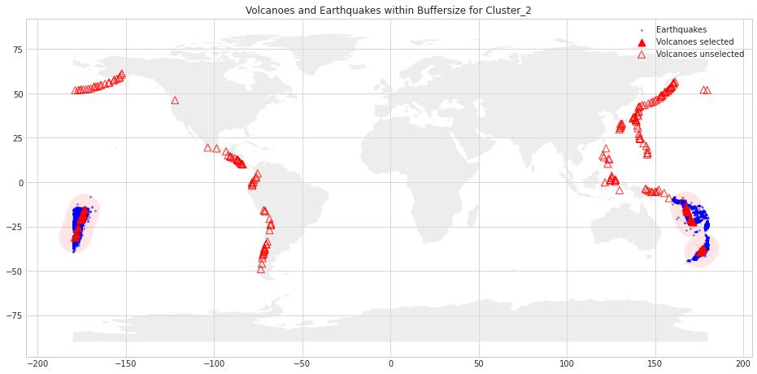

```
2025-01-26 21:08:38,091 - INFO - save_dataset: Data saved successfully to 'data/scope/reclustered_1000/cluster_Cluster_2/earthquakes_spatially_selected_250126-210837.csv'.
2025-01-26 21:08:38,433 - INFO - save_dataset: Data saved successfully to 'data/scope/reclustered_1000/cluster_Cluster_2/earthquakes_spatially_selected.csv'.
2025-01-26 21:08:38,438 - INFO - save_dataset: Data saved successfully to 'data/scope/reclustered_1000/cluster_Cluster_2/volcanoes_spatially_selected_250126-210838.csv'.
2025-01-26 21:08:38,441 - INFO - save_dataset: Data saved successfully to 'data/scope/reclustered_1000/cluster_Cluster_2/volcanoes_spatially_selected.csv'.
2025-01-26 21:08:38,445 - INFO - save_dataset: Data saved successfully to 'data/scope/reclustered_1000/cluster_Cluster_2/eruptions_spatially_selected_250126-210838.csv'.
2025-01-26 21:08:38,448 - INFO - save_dataset: Data saved successfully to 'data/scope/reclustered_1000/cluster_Cluster_2/eruptions_spatially_selected.csv'.
```

```
========================================================================================================================
ID 3
region_name = Cluster_3
Number of cluster points = 29
Number of filtered volcanoes = 29
```

```
2025-01-26 21:08:38,955 - INFO - 253_spatial_operations_gvp_reclustering.ipynb: Number of rows is EQUAL. Cluster (region) Cluster_3 has 29 vocanoes.
```

```
Number of filtered eruptions = 243
```

```
2025-01-26 21:08:39,460 - INFO - 253_spatial_operations_gvp_reclustering.ipynb: Set data directory for saving to './data/scope/reclustered_1000/cluster_Cluster_3'.
```

```
Earthquakes selected: 3964
```

```
2025-01-26 21:08:40,075 - INFO - 253_spatial_operations_gvp_reclustering.ipynb: Saving 25_Buffered_Earthquakes.png to './data/scope/reclustered_1000/cluster_Cluster_3'.
```

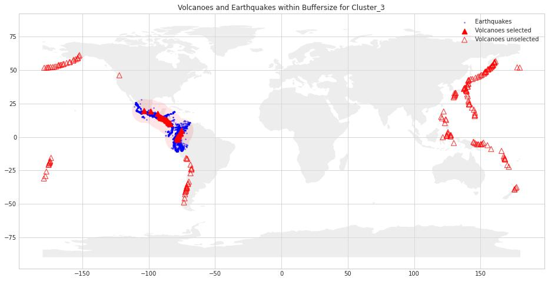

```
2025-01-26 21:08:40,275 - INFO - save_dataset: Data saved successfully to 'data/scope/reclustered_1000/cluster_Cluster_3/earthquakes_spatially_selected_250126-210840.csv'.
2025-01-26 21:08:40,364 - INFO - save_dataset: Data saved successfully to 'data/scope/reclustered_1000/cluster_Cluster_3/earthquakes_spatially_selected.csv'.
2025-01-26 21:08:40,368 - INFO - save_dataset: Data saved successfully to 'data/scope/reclustered_1000/cluster_Cluster_3/volcanoes_spatially_selected_250126-210840.csv'.
2025-01-26 21:08:40,372 - INFO - save_dataset: Data saved successfully to 'data/scope/reclustered_1000/cluster_Cluster_3/volcanoes_spatially_selected.csv'.
2025-01-26 21:08:40,377 - INFO - save_dataset: Data saved successfully to 'data/scope/reclustered_1000/cluster_Cluster_3/eruptions_spatially_selected_250126-210840.csv'.
2025-01-26 21:08:40,382 - INFO - save_dataset: Data saved successfully to 'data/scope/reclustered_1000/cluster_Cluster_3/eruptions_spatially_selected.csv'.
```

```
========================================================================================================================
ID 4
region_name = Cluster_4
Number of cluster points = 36
Number of filtered volcanoes = 36
```

```
2025-01-26 21:08:40,888 - INFO - 253_spatial_operations_gvp_reclustering.ipynb: Number of rows is EQUAL. Cluster (region) Cluster_4 has 36 vocanoes.
```

```
Number of filtered eruptions = 194
```

```
2025-01-26 21:08:41,394 - INFO - 253_spatial_operations_gvp_reclustering.ipynb: Set data directory for saving to './data/scope/reclustered_1000/cluster_Cluster_4'.
```

```
Earthquakes selected: 7629
```

```
2025-01-26 21:08:42,043 - INFO - 253_spatial_operations_gvp_reclustering.ipynb: Saving 25_Buffered_Earthquakes.png to './data/scope/reclustered_1000/cluster_Cluster_4'.
```

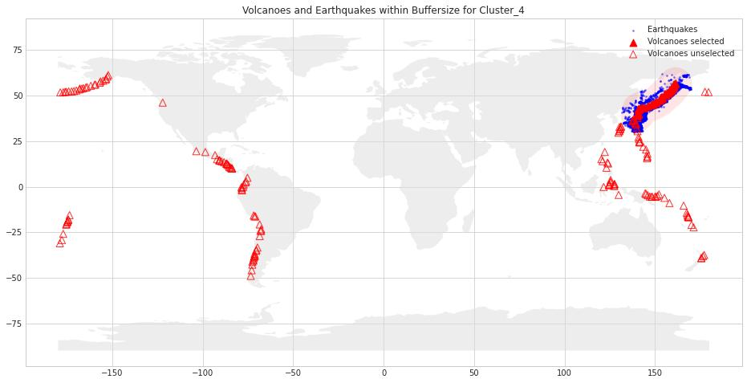

```
2025-01-26 21:08:42,280 - INFO - save_dataset: Data saved successfully to 'data/scope/reclustered_1000/cluster_Cluster_4/earthquakes_spatially_selected_250126-210842.csv'.
2025-01-26 21:08:42,411 - INFO - save_dataset: Data saved successfully to 'data/scope/reclustered_1000/cluster_Cluster_4/earthquakes_spatially_selected.csv'.
2025-01-26 21:08:42,415 - INFO - save_dataset: Data saved successfully to 'data/scope/reclustered_1000/cluster_Cluster_4/volcanoes_spatially_selected_250126-210842.csv'.
2025-01-26 21:08:42,418 - INFO - save_dataset: Data saved successfully to 'data/scope/reclustered_1000/cluster_Cluster_4/volcanoes_spatially_selected.csv'.
2025-01-26 21:08:42,422 - INFO - save_dataset: Data saved successfully to 'data/scope/reclustered_1000/cluster_Cluster_4/eruptions_spatially_selected_250126-210842.csv'.
2025-01-26 21:08:42,425 - INFO - save_dataset: Data saved successfully to 'data/scope/reclustered_1000/cluster_Cluster_4/eruptions_spatially_selected.csv'.
```

```
========================================================================================================================
ID 5
region_name = Cluster_5
Number of cluster points = 25
Number of filtered volcanoes = 25
```

```
2025-01-26 21:08:42,930 - INFO - 253_spatial_operations_gvp_reclustering.ipynb: Number of rows is EQUAL. Cluster (region) Cluster_5 has 25 vocanoes.
```

```
Number of filtered eruptions = 212
```

```
2025-01-26 21:08:43,434 - INFO - 253_spatial_operations_gvp_reclustering.ipynb: Set data directory for saving to './data/scope/reclustered_1000/cluster_Cluster_5'.
```

```
Earthquakes selected: 19568
```

```
2025-01-26 21:08:44,678 - INFO - 253_spatial_operations_gvp_reclustering.ipynb: Saving 25_Buffered_Earthquakes.png to './data/scope/reclustered_1000/cluster_Cluster_5'.
```

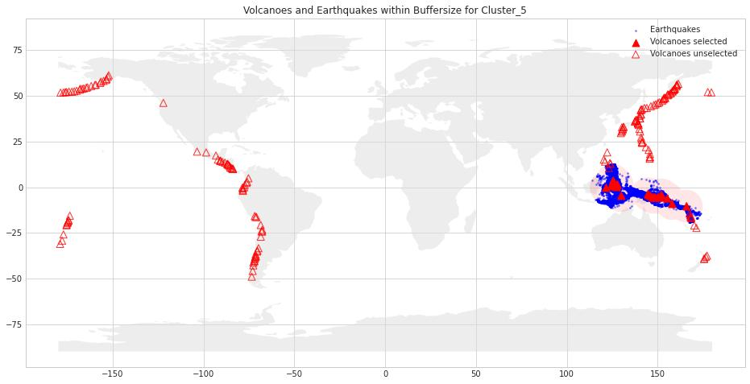

```
2025-01-26 21:08:45,147 - INFO - save_dataset: Data saved successfully to 'data/scope/reclustered_1000/cluster_Cluster_5/earthquakes_spatially_selected_250126-210844.csv'.
2025-01-26 21:08:45,475 - INFO - save_dataset: Data saved successfully to 'data/scope/reclustered_1000/cluster_Cluster_5/earthquakes_spatially_selected.csv'.
2025-01-26 21:08:45,479 - INFO - save_dataset: Data saved successfully to 'data/scope/reclustered_1000/cluster_Cluster_5/volcanoes_spatially_selected_250126-210845.csv'.
2025-01-26 21:08:45,482 - INFO - save_dataset: Data saved successfully to 'data/scope/reclustered_1000/cluster_Cluster_5/volcanoes_spatially_selected.csv'.
2025-01-26 21:08:45,486 - INFO - save_dataset: Data saved successfully to 'data/scope/reclustered_1000/cluster_Cluster_5/eruptions_spatially_selected_250126-210845.csv'.
2025-01-26 21:08:45,490 - INFO - save_dataset: Data saved successfully to 'data/scope/reclustered_1000/cluster_Cluster_5/eruptions_spatially_selected.csv'.
```

```
========================================================================================================================
ID 6
region_name = Cluster_6
Number of cluster points = 27
Number of filtered volcanoes = 27
```

```
2025-01-26 21:08:45,995 - INFO - 253_spatial_operations_gvp_reclustering.ipynb: Number of rows is EQUAL. Cluster (region) Cluster_6 has 27 vocanoes.
```

```
Number of filtered eruptions = 147
```

```
2025-01-26 21:08:46,499 - INFO - 253_spatial_operations_gvp_reclustering.ipynb: Set data directory for saving to './data/scope/reclustered_1000/cluster_Cluster_6'.
```

```
Earthquakes selected: 2948
```

```
2025-01-26 21:08:47,112 - INFO - 253_spatial_operations_gvp_reclustering.ipynb: Saving 25_Buffered_Earthquakes.png to './data/scope/reclustered_1000/cluster_Cluster_6'.
```

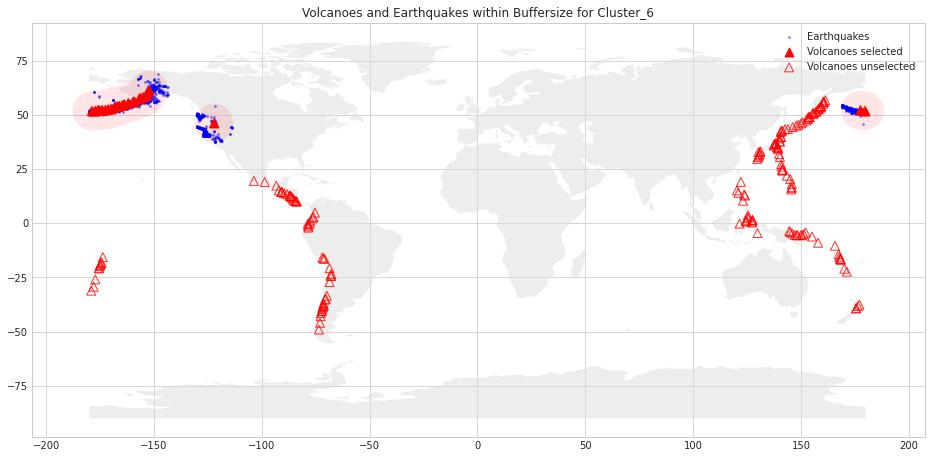

```
2025-01-26 21:08:47,252 - INFO - save_dataset: Data saved successfully to 'data/scope/reclustered_1000/cluster_Cluster_6/earthquakes_spatially_selected_250126-210847.csv'.
2025-01-26 21:08:47,305 - INFO - save_dataset: Data saved successfully to 'data/scope/reclustered_1000/cluster_Cluster_6/earthquakes_spatially_selected.csv'.
2025-01-26 21:08:47,308 - INFO - save_dataset: Data saved successfully to 'data/scope/reclustered_1000/cluster_Cluster_6/volcanoes_spatially_selected_250126-210847.csv'.
2025-01-26 21:08:47,311 - INFO - save_dataset: Data saved successfully to 'data/scope/reclustered_1000/cluster_Cluster_6/volcanoes_spatially_selected.csv'.
2025-01-26 21:08:47,314 - INFO - save_dataset: Data saved successfully to 'data/scope/reclustered_1000/cluster_Cluster_6/eruptions_spatially_selected_250126-210847.csv'.
2025-01-26 21:08:47,318 - INFO - save_dataset: Data saved successfully to 'data/scope/reclustered_1000/cluster_Cluster_6/eruptions_spatially_selected.csv'.
```

```python
# set cluster code for selected clustering method
cluster_code = 'cluster_ward'

# loop over all unique regions
for cluster in sorted(volcanoes_selected_gdf_results[cluster_code].unique()):
    # new cluster
    print("="*120)
    print(f"ID {cluster}")

    # filter rows for the current cluster
    volcano_numbers = volcanoes_selected_gdf_results[volcanoes_selected_gdf_results['cluster_ward'] == cluster]['Volcano_Number']

    # subset of volcanoes in this cluster
    volcanoes_selected_gdf_subset = volcanoes_selected_gdf[volcanoes_selected_gdf['Volcano_Number'].isin(volcano_numbers)].copy()

    # construct a Region name
    region_name = "Cluster_" + str(cluster)
    print(f"region_name = {region_name}")
    print(f"Number of cluster points = {len(volcano_numbers)}")
    print(f"Number of filtered volcanoes = {len(volcanoes_selected_gdf_subset)}")
    time.sleep(0.5)

    # check consistence of filtered volcanoes
    if len(volcano_numbers) == len(volcanoes_selected_gdf_subset):
        logging.info(f"{script_name}: Number of rows is EQUAL. Cluster (region) {region_name} has {len(volcano_numbers)} vocanoes.")
    else:
        print(f"Number of rows is NOT EQUAL. Expected {len(volcano_numbers)}, but got {len(volcanoes_selected_gdf_subset)}.")
        logging.error(f"{script_name}: Number of rows is NOT EQUAL. Cluster (region) {region_name} has {len(volcano_numbers)} vocanoes but got {len(volcanoes_selected_gdf_subset)}.")
        sys.exit()

    # filter eruptions_selected to only include rows where Volcano_Number exists in volcanoes_selected_gdf_subset
    eruptions_selected_subset = eruptions_selected[
        eruptions_selected['Volcano_Number'].isin(volcanoes_selected_gdf_subset['Volcano_Number'])
    ]
    print(f"Number of filtered eruptions = {len(eruptions_selected_subset)}")

    # create a new feature with the new cluster name
    volcanoes_selected_gdf_subset['region_name'] = region_name

    # set individual datadir for saving and ensure it is in place
    time.sleep(0.5)
    data_dir_cluster = os.path.join(data_dir, "cluster_" + str(region_name))
    os.makedirs(data_dir_cluster, exist_ok=True)
    logging.info(f"{script_name}: Set data directory for saving to './{data_dir_cluster}'.")

    # make a new geopandas dataframe
    volcanoes_selected_gdf_buffers = volcanoes_selected_gdf_subset[
        ['Volcano_Number', 'Volcano_Name', 'Region', 'geometry']].copy()

    # buffer distance in meters
    buffer_distance = parameters.buffer_size_km * 1000

    # generate a buffer with different radius for lat/lon
    volcanoes_selected_gdf_buffers['geometry'] = volcanoes_selected_gdf_subset.apply(
        lambda row: row.geometry.buffer(
            meters_to_degrees(buffer_distance, row.geometry.y)[0]
        ), axis=1
    )

    # combine all single buffers into a single buffer
    volcano_buffers_combined = volcanoes_selected_gdf_buffers['geometry'].unary_union

    # Find rows in 'eq' that are spatially inside 'volcano_geometry'
    earthquakes_spatially_selected_gdf = \
        earthquakes_selected_gdf[earthquakes_selected_gdf['geometry'].within(volcano_buffers_combined)]
    print(f'Earthquakes selected: {len(earthquakes_spatially_selected_gdf)}')

    # show the complete results (volcanoes & earthquakes)
    fig, ax = plt.subplots(figsize=(16, 10))
    plt.style.use('seaborn-whitegrid')
    world.plot(ax=ax, color="#dddddd", edgecolor=None, alpha=0.5)
    gpd.GeoSeries([volcano_buffers_combined]).plot(ax=ax, color='red', alpha=0.1, edgecolor=None, label='Buffer')
    earthquakes_spatially_selected_gdf.plot(ax=ax, color='blue', marker='o', label='Earthquakes', markersize=3, alpha=0.4)
    volcanoes_selected_gdf_subset.plot(ax=ax, markersize=80, color='red', alpha=1.0, label='Volcanoes selected', marker='^')
    volcanoes_selected_gdf.plot(ax=ax, markersize=80, color='none', edgecolor="red", alpha=0.8, label='Volcanoes unselected', marker='^')
    plt.title(f'Volcanoes and Earthquakes within Buffersize for {region_name}')
    plt.legend()
    plt.savefig(os.path.join(data_dir_cluster, "25_Buffered_Earthquakes.png"), format='png', dpi=150, bbox_inches='tight')
    logging.info(f"{script_name}: Saving 25_Buffered_Earthquakes.png to './{data_dir_cluster}'.")
    plt.show()

    # save spatially selected earthquake dataset (for this cluster)
    save_dataset(data_file = "earthquakes_spatially_selected.csv",
                 data_dir = data_dir_cluster,
                 data_set = earthquakes_spatially_selected_gdf,
                 append_datetime=True,
                 overwrite_file=False
                )
    # save spatially selected earthquake dataset (for this cluster)
    save_dataset(data_file = "earthquakes_spatially_selected.csv",
                 data_dir = data_dir_cluster,
                 data_set = earthquakes_spatially_selected_gdf,
                 append_datetime=False,
                 overwrite_file=True
                )

    # save spatially selected volcanoes dataset (for this cluster)
    save_dataset(data_file = "volcanoes_spatially_selected.csv",
                 data_dir = data_dir_cluster,
                 data_set = volcanoes_selected_gdf_subset,
                 append_datetime=True,
                 overwrite_file=False
                )
    # save spatially selected volcanoes dataset (for this cluster)
    save_dataset(data_file = "volcanoes_spatially_selected.csv",
                 data_dir = data_dir_cluster,
                 data_set = volcanoes_selected_gdf_subset,
                 append_datetime=False,
                 overwrite_file=True
                )

    # save spatially selected eruptions dataset (for this cluster)
    save_dataset(data_file = "eruptions_spatially_selected.csv",
                 data_dir = data_dir_cluster,
                 data_set = eruptions_selected_subset,
                 append_datetime=True,
                 overwrite_file=False
                )
    # save spatially selected eruptions dataset (for this cluster)
    save_dataset(data_file = "eruptions_spatially_selected.csv",
                 data_dir = data_dir_cluster,
                 data_set = eruptions_selected_subset,
                 append_datetime=False,
                 overwrite_file=True
                )

# last cluster
print("="*120)
```

## End of script

```python
# log the end of this script
logging.info(f"End of script '{script_name}'.")
```

```
2025-01-26 21:08:47,324 - INFO - End of script '253_spatial_operations_gvp_reclustering.ipynb'.
```

## Appendix

```python
%%js

// -------------------------------------------
// What are the headings of this document?
// --> Get a better overview of the structure.
// -------------------------------------------

function listHeadings() {
    let headings = [];
    let cells = Jupyter.notebook.get_cells();

    cells.forEach((cell) => {
        if (cell.cell_type == 'markdown') {
            let text = cell.get_text();
            let lines = text.split('\n');

            lines.forEach((line) => {
                let match = line.match(/^(#+)\s+(.*)/);
                if (match) {
                    headings.push({
                        level: match[1].length, // Number of # symbols indicates the heading level
                        text: match[2].trim()
                    });
                }
            });
        }
    });
    return headings;
}

let headings = listHeadings();
headings.forEach((heading) => {
    let markdown = `${'#'.repeat(heading.level)} ${heading.text}`;
    element.append(`${markdown}<br>`);
});
```

## Save notebook as experimentation protocol

```python
# save notebook as a experimentation protocol
time.sleep(2)
display(Javascript('IPython.notebook.save_checkpoint();'))
time.sleep(2)
save_notebook_as_html(script_name, data_dir)
```